# csc478_assignment2

Sojeong Yang  
CSC 478 Assignment 2

## 1. K-Nearest_Neighbor (KNN) classification

```python
import numpy as np
import pandas as pd
import matplotlib.pyplot as plt
%matplotlib inline
```

load and check the data:

```python
# modifiedterms.txt
modified_terms = pd.read_csv("./newsgroups/modifiedterms.txt", header=None)
modified_terms
```

|  | 0 |
| --- | --- |
| 0 | david |
| 1 | rex |
| 2 | wood |
| 3 | subject |
| 4 | call |
| ... | ... |
| 5495 | shear |
| 5496 | handi |
| 5497 | inexperienc |
| 5498 | markw |
| 5499 | pspmf3gpsemicom |

5500 rows × 1 columns

```python
# testClasses.txt
test_classes = pd.read_csv("./newsgroups/testClasses.txt", header=None, delimiter='\t')
test_classes
```

|  | 0 | 1 |
| --- | --- | --- |
| 0 | 0 | 1 |
| 1 | 1 | 0 |
| 2 | 2 | 0 |
| 3 | 3 | 1 |
| 4 | 4 | 1 |
| ... | ... | ... |
| 195 | 195 | 1 |
| 196 | 196 | 1 |
| 197 | 197 | 0 |
| 198 | 198 | 1 |
| 199 | 199 | 1 |

200 rows × 2 columns

```python
# remove the column containing the terms
test_c = np.array(test_classes.iloc[:,1])
test_c.shape
```

```
(200,)
```

```python
# testMatrixModified.txt
test_matrix = pd.read_csv("./newsgroups/testMatrixModified.txt", header=None, delimiter='\t')
test_matrix
```

|  | 0 | 1 | 2 | 3 | 4 | 5 | 6 | 7 | 8 | 9 | ... | 190 | 191 | 192 | 193 | 194 | 195 | 196 | 197 | 198 | 199 |
| --- | --- | --- | --- | --- | --- | --- | --- | --- | --- | --- | --- | --- | --- | --- | --- | --- | --- | --- | --- | --- | --- |
| 0 | 0.0 | 0.0 | 1.0 | 0.0 | 0.0 | 0.0 | 0.0 | 0.0 | 0.0 | 0.0 | ... | 0.0 | 0.0 | 0.0 | 0.0 | 0.0 | 0.0 | 0.0 | 0.0 | 0.0 | 0.0 |
| 1 | 0.0 | 0.0 | 0.0 | 0.0 | 0.0 | 0.0 | 0.0 | 0.0 | 0.0 | 0.0 | ... | 0.0 | 0.0 | 0.0 | 0.0 | 0.0 | 0.0 | 0.0 | 0.0 | 0.0 | 0.0 |
| 2 | 0.0 | 0.0 | 0.0 | 0.0 | 0.0 | 0.0 | 0.0 | 0.0 | 0.0 | 0.0 | ... | 0.0 | 0.0 | 0.0 | 0.0 | 0.0 | 0.0 | 0.0 | 0.0 | 0.0 | 0.0 |
| 3 | 1.0 | 1.0 | 1.0 | 1.0 | 1.0 | 1.0 | 2.0 | 1.0 | 1.0 | 1.0 | ... | 1.0 | 2.0 | 1.0 | 1.0 | 1.0 | 1.0 | 1.0 | 1.0 | 1.0 | 1.0 |
| 4 | 0.0 | 0.0 | 0.0 | 0.0 | 0.0 | 0.0 | 0.0 | 0.0 | 2.0 | 0.0 | ... | 0.0 | 0.0 | 0.0 | 0.0 | 0.0 | 0.0 | 0.0 | 0.0 | 0.0 | 0.0 |
| ... | ... | ... | ... | ... | ... | ... | ... | ... | ... | ... | ... | ... | ... | ... | ... | ... | ... | ... | ... | ... | ... |
| 5495 | 0.0 | 0.0 | 0.0 | 0.0 | 0.0 | 0.0 | 0.0 | 0.0 | 0.0 | 0.0 | ... | 0.0 | 0.0 | 0.0 | 0.0 | 0.0 | 0.0 | 0.0 | 0.0 | 0.0 | 0.0 |
| 5496 | 0.0 | 0.0 | 0.0 | 0.0 | 0.0 | 0.0 | 0.0 | 0.0 | 0.0 | 0.0 | ... | 0.0 | 0.0 | 0.0 | 0.0 | 0.0 | 0.0 | 0.0 | 0.0 | 0.0 | 0.0 |
| 5497 | 0.0 | 0.0 | 0.0 | 0.0 | 0.0 | 0.0 | 0.0 | 0.0 | 0.0 | 0.0 | ... | 0.0 | 0.0 | 0.0 | 0.0 | 0.0 | 0.0 | 0.0 | 0.0 | 0.0 | 0.0 |
| 5498 | 0.0 | 0.0 | 0.0 | 0.0 | 0.0 | 0.0 | 0.0 | 0.0 | 0.0 | 0.0 | ... | 0.0 | 0.0 | 0.0 | 0.0 | 0.0 | 0.0 | 0.0 | 0.0 | 0.0 | 0.0 |
| 5499 | 0.0 | 0.0 | 0.0 | 0.0 | 0.0 | 0.0 | 0.0 | 0.0 | 0.0 | 0.0 | ... | 0.0 | 0.0 | 0.0 | 0.0 | 0.0 | 0.0 | 0.0 | 0.0 | 0.0 | 0.0 |

5500 rows × 200 columns

```python
test_matrix.shape
```

```
(5500, 200)
```

```python
# trainClasses.txt
train_classes = pd.read_csv("./newsgroups/trainClasses.txt", header=None, delimiter='\t')
train_classes
```

|  | 0 | 1 |
| --- | --- | --- |
| 0 | 0 | 0 |
| 1 | 1 | 1 |
| 2 | 2 | 0 |
| 3 | 3 | 1 |
| 4 | 4 | 0 |
| ... | ... | ... |
| 795 | 795 | 0 |
| 796 | 796 | 1 |
| 797 | 797 | 1 |
| 798 | 798 | 1 |
| 799 | 799 | 1 |

800 rows × 2 columns

```python
# remove the column containing the terms
train_c = np.array(train_classes.iloc[:,1])
train_c.shape
```

```
(800,)
```

```python
# trainMatrixModified.txt
train_matrix = pd.read_csv("./newsgroups/trainMatrixModified.txt", header=None, delimiter='\t')
train_matrix
```

|  | 0 | 1 | 2 | 3 | 4 | 5 | 6 | 7 | 8 | 9 | ... | 790 | 791 | 792 | 793 | 794 | 795 | 796 | 797 | 798 | 799 |
| --- | --- | --- | --- | --- | --- | --- | --- | --- | --- | --- | --- | --- | --- | --- | --- | --- | --- | --- | --- | --- | --- |
| 0 | 2.0 | 0.0 | 0.0 | 2.0 | 2.0 | 0.0 | 0.0 | 0.0 | 0.0 | 0.0 | ... | 0.0 | 0.0 | 0.0 | 0.0 | 0.0 | 0.0 | 0.0 | 0.0 | 0.0 | 0.0 |
| 1 | 2.0 | 0.0 | 0.0 | 0.0 | 0.0 | 0.0 | 0.0 | 0.0 | 0.0 | 0.0 | ... | 0.0 | 0.0 | 3.0 | 0.0 | 0.0 | 0.0 | 0.0 | 0.0 | 0.0 | 0.0 |
| 2 | 2.0 | 0.0 | 0.0 | 0.0 | 0.0 | 0.0 | 0.0 | 0.0 | 0.0 | 0.0 | ... | 0.0 | 0.0 | 0.0 | 0.0 | 0.0 | 0.0 | 0.0 | 0.0 | 0.0 | 0.0 |
| 3 | 1.0 | 1.0 | 1.0 | 1.0 | 1.0 | 1.0 | 2.0 | 1.0 | 1.0 | 1.0 | ... | 1.0 | 1.0 | 1.0 | 1.0 | 1.0 | 1.0 | 1.0 | 1.0 | 1.0 | 1.0 |
| 4 | 8.0 | 1.0 | 0.0 | 0.0 | 0.0 | 0.0 | 0.0 | 0.0 | 0.0 | 0.0 | ... | 0.0 | 0.0 | 2.0 | 0.0 | 0.0 | 0.0 | 0.0 | 0.0 | 0.0 | 1.0 |
| ... | ... | ... | ... | ... | ... | ... | ... | ... | ... | ... | ... | ... | ... | ... | ... | ... | ... | ... | ... | ... | ... |
| 5495 | 0.0 | 0.0 | 0.0 | 0.0 | 0.0 | 0.0 | 0.0 | 0.0 | 0.0 | 0.0 | ... | 0.0 | 0.0 | 0.0 | 0.0 | 0.0 | 0.0 | 0.0 | 0.0 | 0.0 | 0.0 |
| 5496 | 0.0 | 0.0 | 0.0 | 0.0 | 0.0 | 0.0 | 0.0 | 0.0 | 0.0 | 0.0 | ... | 0.0 | 0.0 | 0.0 | 0.0 | 0.0 | 0.0 | 0.0 | 0.0 | 0.0 | 0.0 |
| 5497 | 0.0 | 0.0 | 0.0 | 0.0 | 0.0 | 0.0 | 0.0 | 0.0 | 0.0 | 0.0 | ... | 0.0 | 0.0 | 0.0 | 0.0 | 0.0 | 0.0 | 0.0 | 0.0 | 0.0 | 0.0 |
| 5498 | 0.0 | 0.0 | 0.0 | 0.0 | 0.0 | 0.0 | 0.0 | 0.0 | 0.0 | 0.0 | ... | 0.0 | 0.0 | 0.0 | 0.0 | 0.0 | 0.0 | 0.0 | 0.0 | 0.0 | 0.0 |
| 5499 | 0.0 | 0.0 | 0.0 | 0.0 | 0.0 | 0.0 | 0.0 | 0.0 | 0.0 | 0.0 | ... | 0.0 | 0.0 | 0.0 | 0.0 | 0.0 | 0.0 | 0.0 | 0.0 | 0.0 | 0.0 |

5500 rows × 800 columns

```python
train_matrix.shape
```

```
(5500, 800)
```

```python
# transpose the matrix to document-term(DT) matrix
test_matrix_T = test_matrix.T
test_matrix_T
```

|  | 0 | 1 | 2 | 3 | 4 | 5 | 6 | 7 | 8 | 9 | ... | 5490 | 5491 | 5492 | 5493 | 5494 | 5495 | 5496 | 5497 | 5498 | 5499 |
| --- | --- | --- | --- | --- | --- | --- | --- | --- | --- | --- | --- | --- | --- | --- | --- | --- | --- | --- | --- | --- | --- |
| 0 | 0.0 | 0.0 | 0.0 | 1.0 | 0.0 | 0.0 | 0.0 | 0.0 | 0.0 | 1.0 | ... | 0.0 | 0.0 | 0.0 | 0.0 | 0.0 | 0.0 | 0.0 | 0.0 | 0.0 | 0.0 |
| 1 | 0.0 | 0.0 | 0.0 | 1.0 | 0.0 | 0.0 | 0.0 | 0.0 | 0.0 | 0.0 | ... | 0.0 | 0.0 | 0.0 | 0.0 | 0.0 | 0.0 | 0.0 | 0.0 | 0.0 | 0.0 |
| 2 | 1.0 | 0.0 | 0.0 | 1.0 | 0.0 | 0.0 | 0.0 | 0.0 | 0.0 | 0.0 | ... | 0.0 | 0.0 | 0.0 | 0.0 | 0.0 | 0.0 | 0.0 | 0.0 | 0.0 | 0.0 |
| 3 | 0.0 | 0.0 | 0.0 | 1.0 | 0.0 | 0.0 | 0.0 | 0.0 | 0.0 | 0.0 | ... | 0.0 | 0.0 | 0.0 | 0.0 | 0.0 | 0.0 | 0.0 | 0.0 | 0.0 | 0.0 |
| 4 | 0.0 | 0.0 | 0.0 | 1.0 | 0.0 | 0.0 | 0.0 | 0.0 | 0.0 | 1.0 | ... | 0.0 | 0.0 | 0.0 | 0.0 | 0.0 | 0.0 | 0.0 | 0.0 | 0.0 | 0.0 |
| ... | ... | ... | ... | ... | ... | ... | ... | ... | ... | ... | ... | ... | ... | ... | ... | ... | ... | ... | ... | ... | ... |
| 195 | 0.0 | 0.0 | 0.0 | 1.0 | 0.0 | 0.0 | 0.0 | 0.0 | 0.0 | 1.0 | ... | 1.0 | 1.0 | 0.0 | 0.0 | 0.0 | 0.0 | 0.0 | 0.0 | 0.0 | 0.0 |
| 196 | 0.0 | 0.0 | 0.0 | 1.0 | 0.0 | 0.0 | 0.0 | 0.0 | 0.0 | 0.0 | ... | 0.0 | 0.0 | 0.0 | 0.0 | 0.0 | 0.0 | 0.0 | 0.0 | 0.0 | 0.0 |
| 197 | 0.0 | 0.0 | 0.0 | 1.0 | 0.0 | 0.0 | 0.0 | 0.0 | 0.0 | 0.0 | ... | 0.0 | 0.0 | 0.0 | 0.0 | 0.0 | 0.0 | 0.0 | 0.0 | 0.0 | 0.0 |
| 198 | 0.0 | 0.0 | 0.0 | 1.0 | 0.0 | 0.0 | 0.0 | 0.0 | 0.0 | 1.0 | ... | 0.0 | 0.0 | 0.0 | 0.0 | 0.0 | 0.0 | 0.0 | 0.0 | 0.0 | 0.0 |
| 199 | 0.0 | 0.0 | 0.0 | 1.0 | 0.0 | 0.0 | 0.0 | 0.0 | 0.0 | 0.0 | ... | 0.0 | 0.0 | 0.0 | 0.0 | 0.0 | 0.0 | 0.0 | 0.0 | 0.0 | 0.0 |

200 rows × 5500 columns

```python
test_matrix_T.shape
```

```
(200, 5500)
```

```python
# transpose the matrix to document-term(DT) matrix
train_matrix_T = train_matrix.T
train_matrix_T
```

|  | 0 | 1 | 2 | 3 | 4 | 5 | 6 | 7 | 8 | 9 | ... | 5490 | 5491 | 5492 | 5493 | 5494 | 5495 | 5496 | 5497 | 5498 | 5499 |
| --- | --- | --- | --- | --- | --- | --- | --- | --- | --- | --- | --- | --- | --- | --- | --- | --- | --- | --- | --- | --- | --- |
| 0 | 2.0 | 2.0 | 2.0 | 1.0 | 8.0 | 6.0 | 2.0 | 8.0 | 2.0 | 4.0 | ... | 0.0 | 0.0 | 0.0 | 0.0 | 0.0 | 0.0 | 0.0 | 0.0 | 0.0 | 0.0 |
| 1 | 0.0 | 0.0 | 0.0 | 1.0 | 1.0 | 0.0 | 0.0 | 0.0 | 0.0 | 0.0 | ... | 0.0 | 0.0 | 0.0 | 0.0 | 0.0 | 0.0 | 0.0 | 0.0 | 0.0 | 0.0 |
| 2 | 0.0 | 0.0 | 0.0 | 1.0 | 0.0 | 0.0 | 0.0 | 2.0 | 0.0 | 1.0 | ... | 0.0 | 0.0 | 0.0 | 0.0 | 0.0 | 0.0 | 0.0 | 0.0 | 0.0 | 0.0 |
| 3 | 2.0 | 0.0 | 0.0 | 1.0 | 0.0 | 0.0 | 0.0 | 0.0 | 0.0 | 0.0 | ... | 0.0 | 0.0 | 0.0 | 0.0 | 0.0 | 0.0 | 0.0 | 0.0 | 0.0 | 0.0 |
| 4 | 2.0 | 0.0 | 0.0 | 1.0 | 0.0 | 0.0 | 0.0 | 0.0 | 0.0 | 0.0 | ... | 0.0 | 0.0 | 0.0 | 0.0 | 0.0 | 0.0 | 0.0 | 0.0 | 0.0 | 0.0 |
| ... | ... | ... | ... | ... | ... | ... | ... | ... | ... | ... | ... | ... | ... | ... | ... | ... | ... | ... | ... | ... | ... |
| 795 | 0.0 | 0.0 | 0.0 | 1.0 | 0.0 | 0.0 | 0.0 | 0.0 | 0.0 | 0.0 | ... | 0.0 | 0.0 | 0.0 | 0.0 | 0.0 | 0.0 | 0.0 | 0.0 | 0.0 | 0.0 |
| 796 | 0.0 | 0.0 | 0.0 | 1.0 | 0.0 | 0.0 | 0.0 | 0.0 | 0.0 | 0.0 | ... | 0.0 | 0.0 | 0.0 | 0.0 | 0.0 | 0.0 | 0.0 | 0.0 | 0.0 | 0.0 |
| 797 | 0.0 | 0.0 | 0.0 | 1.0 | 0.0 | 0.0 | 0.0 | 0.0 | 0.0 | 0.0 | ... | 0.0 | 0.0 | 0.0 | 0.0 | 0.0 | 0.0 | 0.0 | 0.0 | 0.0 | 0.0 |
| 798 | 0.0 | 0.0 | 0.0 | 1.0 | 0.0 | 0.0 | 0.0 | 0.0 | 0.0 | 0.0 | ... | 0.0 | 0.0 | 0.0 | 0.0 | 0.0 | 0.0 | 0.0 | 0.0 | 0.0 | 0.0 |
| 799 | 0.0 | 0.0 | 0.0 | 1.0 | 1.0 | 0.0 | 0.0 | 0.0 | 0.0 | 0.0 | ... | 0.0 | 0.0 | 0.0 | 0.0 | 0.0 | 0.0 | 0.0 | 0.0 | 0.0 | 0.0 |

800 rows × 5500 columns

```python
train_matrix_T.shape
```

```
(800, 5500)
```

```python
train_matrix_T_arr = np.array(train_matrix_T)
test_matrix_T_arr = np.array(test_matrix_T)

type(train_matrix_T_arr), train_matrix_T_arr.shape, test_matrix_T_arr.shape
```

```
(numpy.ndarray, (800, 5500), (200, 5500))
```

### a. Create your ouwn KNN classifier function.

```python
from collections import Counter

def knn_classifier(x, D, K, measure, classlabel):
    if measure == 0:
        # euclidean distances
        dists = np.sqrt(((D - x)**2).sum(axis=1))
    elif measure == 1:
        D_norm = np.array([np.linalg.norm(D[i]) for i in range(len(D))])
        x_norm = np.linalg.norm(x)
        # cosine
        sims = np.dot(D,x)/(D_norm * x_norm)
        # cosine similarity
        dists = 1 - sims
    idx = np.argsort(dists)
    neigh_idx = idx[:K]
    neigh_labels = classlabel[neigh_idx]
    count = Counter(neigh_labels)
    #print("Labels for top ", K, "neighbors: ", count)

    return neigh_idx[:K], count.most_common(1)[0][0]
```

```python
k = 10
measure = 0 # euclidean similarity
idx, predict = knn_classifier(test_matrix_T_arr[12], train_matrix_T_arr, k, measure, train_c)
print('Index of K nearest neighbors: {}\nPredicted class is: {}'.format(idx, predict))
```

```
Index of K nearest neighbors: [798 757 119 398  38 224 711 615 751  69]
Predicted class is: 0
```

```python
k = 10
measure = 1 # cosine similarity
idx, predict = knn_classifier(test_matrix_T_arr[12], train_matrix_T_arr, k, measure, train_c)
print('Index of K nearest neighbors: {}\nPredicted class is: {}'.format(idx, predict))
```

```
Index of K nearest neighbors: [334 177 233 715 732 510 221 178  94 254]
Predicted class is: 1
```

### b. Create an evaluation function to measure the accuracy of your classifier.

```python
def knn_evaluate(x, D, K, measure, train, classlabel):
    count = 0
    correct = 0.0
    for i in range(x.shape[0]):
        count += 1
        idx, predict = knn_classifier(x[i,:], D, K, measure, train)
        if (predict == classlabel[i]):
            correct += 1.0
    accuracy = correct/count
    return accuracy
```

```python
K = 5
measure = 0 # euclidean similarity
acc = knn_evaluate(test_matrix_T_arr, train_matrix_T_arr, K, measure, train_c, test_c)
acc
```

```
0.815
```

```python
K = 5
measure = 1 # cosine similarity
acc = knn_evaluate(test_matrix_T_arr, train_matrix_T_arr, K, measure, train_c, test_c)
acc
```

```
0.97
```

### c. Run your evalueation function on a range of values for K from 5 to 100

```python
Euclid = []
Cosine = []
```

```python
%%time
for k in range(0, 100, 5):
    Euclid.append(knn_evaluate(test_matrix_T_arr, train_matrix_T_arr, k+5, 0, train_c, test_c))
print(Euclid)
```

```
[0.815, 0.85, 0.785, 0.765, 0.73, 0.725, 0.69, 0.7, 0.655, 0.67, 0.655, 0.66, 0.625, 0.625, 0.63, 0.615, 0.615, 0.61, 0.605, 0.605]
CPU times: user 37.4 s, sys: 6.31 s, total: 43.7 s
Wall time: 43.8 s
```

```python
%%time
for k in range(0, 100, 5):
    Cosine.append(knn_evaluate(test_matrix_T_arr, train_matrix_T_arr, k+5, 1, train_c, test_c))
print(Cosine)
```

```
[0.97, 0.985, 0.985, 0.975, 0.97, 0.98, 0.98, 0.98, 0.975, 0.98, 0.975, 0.98, 0.975, 0.975, 0.975, 0.975, 0.975, 0.975, 0.975, 0.975]
CPU times: user 1min 45s, sys: 222 ms, total: 1min 45s
Wall time: 26.4 s
```

**Present the results as single plot to compare** `eculidean distance vs. Cosine similarity`:

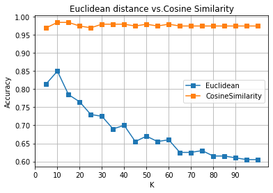

```python
x = list(range(5, 101, 5))
plt.plot(x, Euclid, label='Euclidean', marker="s")
plt.plot(x, Cosine, label='CosineSimilarity', marker="s")
plt.title("Euclidean distance vs.Cosine Similarity")
plt.xlabel("K")
plt.xticks(range(0,100,10))
plt.ylabel("Accuracy")
plt.legend(['Euclidean','CosineSimilarity'], loc="center right")
plt.grid(True)
plt.show()
```

### d. Modify the training and test data sets to TFxIDF weights

```python
# Term Document
TD = train_matrix
TD.shape
```

```
(5500, 800)
```

```python
numTerms = TD.shape[0]
NDocs = TD.shape[1]
```

```python
print(numTerms)
print(NDocs)
```

```
5500
800
```

```python
termFreqs = TD.sum(axis=1)
termFreqs
```

```
0       102.0
1        11.0
2        22.0
3       959.0
4       222.0
        ...
5495      3.0
5496      3.0
5497      2.0
5498      2.0
5499      2.0
Length: 5500, dtype: float64
```

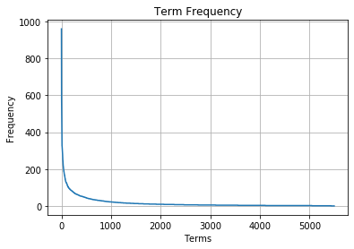

```python
plt.plot(sorted(termFreqs, reverse=True))
plt.title("Term Frequency")
plt.xlabel('Terms')
plt.ylabel('Frequency')
plt.grid(True)
plt.show()
```

```python
DF = pd.DataFrame([(TD!=0).sum(1)]).T
DF
```

|  | 0 |
| --- | --- |
| 0 | 50 |
| 1 | 7 |
| 2 | 10 |
| 3 | 800 |
| 4 | 108 |
| ... | ... |
| 5495 | 3 |
| 5496 | 3 |
| 5497 | 2 |
| 5498 | 2 |
| 5499 | 2 |

5500 rows × 1 columns

```python
# Create a matrix with all entries = NDocs
NMatrix = np.ones(np.shape(TD), dtype = float) * NDocs
np.set_printoptions(precision = 2, suppress=True, linewidth = 120)
print(NMatrix)
```

```
[[800. 800. 800. ... 800. 800. 800.]
 [800. 800. 800. ... 800. 800. 800.]
 [800. 800. 800. ... 800. 800. 800.]
 ...
 [800. 800. 800. ... 800. 800. 800.]
 [800. 800. 800. ... 800. 800. 800.]
 [800. 800. 800. ... 800. 800. 800.]]
```

```python
# Convert into IDF(log of the inverse of doc frequency) values
# compute IDF with training data only
IDF = np.log2(np.divide(NMatrix, np.array(DF)))
IDF
```

```
array([[4.  , 4.  , 4.  , ..., 4.  , 4.  , 4.  ],
       [6.84, 6.84, 6.84, ..., 6.84, 6.84, 6.84],
       [6.32, 6.32, 6.32, ..., 6.32, 6.32, 6.32],
       ...,
       [8.64, 8.64, 8.64, ..., 8.64, 8.64, 8.64],
       [8.64, 8.64, 8.64, ..., 8.64, 8.64, 8.64],
       [8.64, 8.64, 8.64, ..., 8.64, 8.64, 8.64]])
```

```python
# TFxIDF value for each doc-term
TD_tfidf = (TD * IDF).T
pd.set_option("display.precision", 2)
TD_tfidf
```

|  | 0 | 1 | 2 | 3 | 4 | 5 | 6 | 7 | 8 | 9 | ... | 5490 | 5491 | 5492 | 5493 | 5494 | 5495 | 5496 | 5497 | 5498 | 5499 |
| --- | --- | --- | --- | --- | --- | --- | --- | --- | --- | --- | --- | --- | --- | --- | --- | --- | --- | --- | --- | --- | --- |
| 0 | 8.0 | 13.67 | 12.64 | 0.0 | 23.11 | 27.86 | 7.89 | 32.71 | 9.78 | 8.03 | ... | 0.0 | 0.0 | 0.0 | 0.0 | 0.0 | 0.0 | 0.0 | 0.0 | 0.0 | 0.0 |
| 1 | 0.0 | 0.00 | 0.00 | 0.0 | 2.89 | 0.00 | 0.00 | 0.00 | 0.00 | 0.00 | ... | 0.0 | 0.0 | 0.0 | 0.0 | 0.0 | 0.0 | 0.0 | 0.0 | 0.0 | 0.0 |
| 2 | 0.0 | 0.00 | 0.00 | 0.0 | 0.00 | 0.00 | 0.00 | 8.18 | 0.00 | 2.01 | ... | 0.0 | 0.0 | 0.0 | 0.0 | 0.0 | 0.0 | 0.0 | 0.0 | 0.0 | 0.0 |
| 3 | 8.0 | 0.00 | 0.00 | 0.0 | 0.00 | 0.00 | 0.00 | 0.00 | 0.00 | 0.00 | ... | 0.0 | 0.0 | 0.0 | 0.0 | 0.0 | 0.0 | 0.0 | 0.0 | 0.0 | 0.0 |
| 4 | 8.0 | 0.00 | 0.00 | 0.0 | 0.00 | 0.00 | 0.00 | 0.00 | 0.00 | 0.00 | ... | 0.0 | 0.0 | 0.0 | 0.0 | 0.0 | 0.0 | 0.0 | 0.0 | 0.0 | 0.0 |
| ... | ... | ... | ... | ... | ... | ... | ... | ... | ... | ... | ... | ... | ... | ... | ... | ... | ... | ... | ... | ... | ... |
| 795 | 0.0 | 0.00 | 0.00 | 0.0 | 0.00 | 0.00 | 0.00 | 0.00 | 0.00 | 0.00 | ... | 0.0 | 0.0 | 0.0 | 0.0 | 0.0 | 0.0 | 0.0 | 0.0 | 0.0 | 0.0 |
| 796 | 0.0 | 0.00 | 0.00 | 0.0 | 0.00 | 0.00 | 0.00 | 0.00 | 0.00 | 0.00 | ... | 0.0 | 0.0 | 0.0 | 0.0 | 0.0 | 0.0 | 0.0 | 0.0 | 0.0 | 0.0 |
| 797 | 0.0 | 0.00 | 0.00 | 0.0 | 0.00 | 0.00 | 0.00 | 0.00 | 0.00 | 0.00 | ... | 0.0 | 0.0 | 0.0 | 0.0 | 0.0 | 0.0 | 0.0 | 0.0 | 0.0 | 0.0 |
| 798 | 0.0 | 0.00 | 0.00 | 0.0 | 0.00 | 0.00 | 0.00 | 0.00 | 0.00 | 0.00 | ... | 0.0 | 0.0 | 0.0 | 0.0 | 0.0 | 0.0 | 0.0 | 0.0 | 0.0 | 0.0 |
| 799 | 0.0 | 0.00 | 0.00 | 0.0 | 2.89 | 0.00 | 0.00 | 0.00 | 0.00 | 0.00 | ... | 0.0 | 0.0 | 0.0 | 0.0 | 0.0 | 0.0 | 0.0 | 0.0 | 0.0 | 0.0 |

800 rows × 5500 columns

```python
x_tfidf = (test_matrix *IDF[:,0:200]).T
pd.set_option("display.precision", 2)
x_tfidf
```

|  | 0 | 1 | 2 | 3 | 4 | 5 | 6 | 7 | 8 | 9 | ... | 5490 | 5491 | 5492 | 5493 | 5494 | 5495 | 5496 | 5497 | 5498 | 5499 |
| --- | --- | --- | --- | --- | --- | --- | --- | --- | --- | --- | --- | --- | --- | --- | --- | --- | --- | --- | --- | --- | --- |
| 0 | 0.0 | 0.0 | 0.0 | 0.0 | 0.0 | 0.0 | 0.0 | 0.0 | 0.0 | 2.01 | ... | 0.00 | 0.00 | 0.0 | 0.0 | 0.0 | 0.0 | 0.0 | 0.0 | 0.0 | 0.0 |
| 1 | 0.0 | 0.0 | 0.0 | 0.0 | 0.0 | 0.0 | 0.0 | 0.0 | 0.0 | 0.00 | ... | 0.00 | 0.00 | 0.0 | 0.0 | 0.0 | 0.0 | 0.0 | 0.0 | 0.0 | 0.0 |
| 2 | 4.0 | 0.0 | 0.0 | 0.0 | 0.0 | 0.0 | 0.0 | 0.0 | 0.0 | 0.00 | ... | 0.00 | 0.00 | 0.0 | 0.0 | 0.0 | 0.0 | 0.0 | 0.0 | 0.0 | 0.0 |
| 3 | 0.0 | 0.0 | 0.0 | 0.0 | 0.0 | 0.0 | 0.0 | 0.0 | 0.0 | 0.00 | ... | 0.00 | 0.00 | 0.0 | 0.0 | 0.0 | 0.0 | 0.0 | 0.0 | 0.0 | 0.0 |
| 4 | 0.0 | 0.0 | 0.0 | 0.0 | 0.0 | 0.0 | 0.0 | 0.0 | 0.0 | 2.01 | ... | 0.00 | 0.00 | 0.0 | 0.0 | 0.0 | 0.0 | 0.0 | 0.0 | 0.0 | 0.0 |
| ... | ... | ... | ... | ... | ... | ... | ... | ... | ... | ... | ... | ... | ... | ... | ... | ... | ... | ... | ... | ... | ... |
| 195 | 0.0 | 0.0 | 0.0 | 0.0 | 0.0 | 0.0 | 0.0 | 0.0 | 0.0 | 2.01 | ... | 8.64 | 8.64 | 0.0 | 0.0 | 0.0 | 0.0 | 0.0 | 0.0 | 0.0 | 0.0 |
| 196 | 0.0 | 0.0 | 0.0 | 0.0 | 0.0 | 0.0 | 0.0 | 0.0 | 0.0 | 0.00 | ... | 0.00 | 0.00 | 0.0 | 0.0 | 0.0 | 0.0 | 0.0 | 0.0 | 0.0 | 0.0 |
| 197 | 0.0 | 0.0 | 0.0 | 0.0 | 0.0 | 0.0 | 0.0 | 0.0 | 0.0 | 0.00 | ... | 0.00 | 0.00 | 0.0 | 0.0 | 0.0 | 0.0 | 0.0 | 0.0 | 0.0 | 0.0 |
| 198 | 0.0 | 0.0 | 0.0 | 0.0 | 0.0 | 0.0 | 0.0 | 0.0 | 0.0 | 2.01 | ... | 0.00 | 0.00 | 0.0 | 0.0 | 0.0 | 0.0 | 0.0 | 0.0 | 0.0 | 0.0 |
| 199 | 0.0 | 0.0 | 0.0 | 0.0 | 0.0 | 0.0 | 0.0 | 0.0 | 0.0 | 0.00 | ... | 0.00 | 0.00 | 0.0 | 0.0 | 0.0 | 0.0 | 0.0 | 0.0 | 0.0 | 0.0 |

200 rows × 5500 columns

```python
t1 = np.array(x_tfidf)
t2 = np.array(TD_tfidf)
```

```python
tfidf = []
```

```python
%%time
for k in range(0, 100, 5):
    tfidf.append(knn_evaluate(t1, t2, k+5, 1, train_c, test_c)) # measure: cosine similarity
```

```
CPU times: user 8min 52s, sys: 3.05 s, total: 8min 55s
Wall time: 2min 14s
```

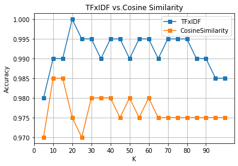

```python
x = list(range(5, 101, 5))
plt.plot(x, tfidf, label='TFxIDF', marker="s")
plt.plot(x, Cosine, label='CosineSimilarity', marker="s")
plt.title("TFxIDF vs.Cosine Similarity")
plt.xlabel("K")
plt.xticks(range(0,100,10))
plt.ylabel("Accuracy")
plt.legend(['TFxIDF','CosineSimilarity'], loc="upper right")
plt.grid(True)
plt.show()
```

### e. Create a new classifier based on the Rocchio Method adapted for test categorization

The `training part` for the classifier can be implemented as a function that takes as input the training data maxtrix and the training labels, returning the prototype vectors for each class:

- For i from (1 to n) let pi = <0, 0,…,0> (init. prototype vectors)  
  For each training example <x, c(x)> in D

  ```
  Let d be the TF/IDF term vector for doc x
  Let i =  j where cj = c(x)
  (sum all the document vectors in ci to get pi)
  Let pi = pi + d
  ```

```python
def rocchio_train(dataMatrix, labels):
    prototype = {}

    for i in set(labels):
        docs = dataMatrix[labels==i]
        p = np.sum(docs, axis=0)
        prototype.update({i:p})
    return prototype
```

```python
pd.DataFrame(t2)
```

|  | 0 | 1 | 2 | 3 | 4 | 5 | 6 | 7 | 8 | 9 | ... | 5490 | 5491 | 5492 | 5493 | 5494 | 5495 | 5496 | 5497 | 5498 | 5499 |
| --- | --- | --- | --- | --- | --- | --- | --- | --- | --- | --- | --- | --- | --- | --- | --- | --- | --- | --- | --- | --- | --- |
| 0 | 8.0 | 13.67 | 12.64 | 0.0 | 23.11 | 27.86 | 7.89 | 32.71 | 9.78 | 8.03 | ... | 0.0 | 0.0 | 0.0 | 0.0 | 0.0 | 0.0 | 0.0 | 0.0 | 0.0 | 0.0 |
| 1 | 0.0 | 0.00 | 0.00 | 0.0 | 2.89 | 0.00 | 0.00 | 0.00 | 0.00 | 0.00 | ... | 0.0 | 0.0 | 0.0 | 0.0 | 0.0 | 0.0 | 0.0 | 0.0 | 0.0 | 0.0 |
| 2 | 0.0 | 0.00 | 0.00 | 0.0 | 0.00 | 0.00 | 0.00 | 8.18 | 0.00 | 2.01 | ... | 0.0 | 0.0 | 0.0 | 0.0 | 0.0 | 0.0 | 0.0 | 0.0 | 0.0 | 0.0 |
| 3 | 8.0 | 0.00 | 0.00 | 0.0 | 0.00 | 0.00 | 0.00 | 0.00 | 0.00 | 0.00 | ... | 0.0 | 0.0 | 0.0 | 0.0 | 0.0 | 0.0 | 0.0 | 0.0 | 0.0 | 0.0 |
| 4 | 8.0 | 0.00 | 0.00 | 0.0 | 0.00 | 0.00 | 0.00 | 0.00 | 0.00 | 0.00 | ... | 0.0 | 0.0 | 0.0 | 0.0 | 0.0 | 0.0 | 0.0 | 0.0 | 0.0 | 0.0 |
| ... | ... | ... | ... | ... | ... | ... | ... | ... | ... | ... | ... | ... | ... | ... | ... | ... | ... | ... | ... | ... | ... |
| 795 | 0.0 | 0.00 | 0.00 | 0.0 | 0.00 | 0.00 | 0.00 | 0.00 | 0.00 | 0.00 | ... | 0.0 | 0.0 | 0.0 | 0.0 | 0.0 | 0.0 | 0.0 | 0.0 | 0.0 | 0.0 |
| 796 | 0.0 | 0.00 | 0.00 | 0.0 | 0.00 | 0.00 | 0.00 | 0.00 | 0.00 | 0.00 | ... | 0.0 | 0.0 | 0.0 | 0.0 | 0.0 | 0.0 | 0.0 | 0.0 | 0.0 | 0.0 |
| 797 | 0.0 | 0.00 | 0.00 | 0.0 | 0.00 | 0.00 | 0.00 | 0.00 | 0.00 | 0.00 | ... | 0.0 | 0.0 | 0.0 | 0.0 | 0.0 | 0.0 | 0.0 | 0.0 | 0.0 | 0.0 |
| 798 | 0.0 | 0.00 | 0.00 | 0.0 | 0.00 | 0.00 | 0.00 | 0.00 | 0.00 | 0.00 | ... | 0.0 | 0.0 | 0.0 | 0.0 | 0.0 | 0.0 | 0.0 | 0.0 | 0.0 | 0.0 |
| 799 | 0.0 | 0.00 | 0.00 | 0.0 | 2.89 | 0.00 | 0.00 | 0.00 | 0.00 | 0.00 | ... | 0.0 | 0.0 | 0.0 | 0.0 | 0.0 | 0.0 | 0.0 | 0.0 | 0.0 | 0.0 |

800 rows × 5500 columns

```python
pd.DataFrame(train_c)
```

|  | 0 |
| --- | --- |
| 0 | 0 |
| 1 | 1 |
| 2 | 0 |
| 3 | 1 |
| 4 | 0 |
| ... | ... |
| 795 | 0 |
| 796 | 1 |
| 797 | 1 |
| 798 | 1 |
| 799 | 1 |

800 rows × 1 columns

```python
prototypes = rocchio_train(t2, train_c)
pd.DataFrame(prototypes)
```

|  | 0 | 1 |
| --- | --- | --- |
| 0 | 228.00 | 180.00 |
| 1 | 27.35 | 47.86 |
| 2 | 31.61 | 107.47 |
| 3 | 0.00 | 0.00 |
| 4 | 453.57 | 187.78 |
| ... | ... | ... |
| 5495 | 16.12 | 8.06 |
| 5496 | 24.18 | 0.00 |
| 5497 | 8.64 | 8.64 |
| 5498 | 17.29 | 0.00 |
| 5499 | 17.29 | 0.00 |

5500 rows × 2 columns

**The** `classification part` **can be implemented as another function that would take as** input the prototypes returned form the training function and the instance to be classified.:

- Given test document x  
  Let d be the TF/IDF term vector for x  
  Let m = –2 (init. maximum cosSim)  
  For i from (1 to n):  
  (compute similarity to prototype vector)  
  Let s = cosSim(d, pi)  
  if s > m

  ```
  let m = s
  let r = ci  (update most similar class prototype)
  ```

  Return class r

```python
def rocchio_classifier(prototype, instance):
    cosSim = []
    m = -2
    for i in range(len(prototype)):
        D_norm = np.linalg.norm(prototype[i])
        x_norm = np.linalg.norm(instance)
        # cosine
        sims = np.dot(prototype[i],instance)/(D_norm * x_norm)
        cosSim.append(sims)
        if sims > m:
            m = sims
            predicted_label = i
    return predicted_label, sims
```

```python
rocchio_classifier(prototypes, t1[0])
```

```
(1, 0.24264174551610868)
```

```python
def rocchio_evaluate(x, D, train_c, classlabel, prototype):
    count = 0
    correct = 0.0
    for i in range(x.shape[0]):
        count += 1
        pred, sim = rocchio_classifier(prototype, x[i])
        if(pred == classlabel[i]):
            correct += 1.0
    accuracy = correct/count
    return accuracy
```

```python
final = rocchio_evaluate(t1, t2, train_c, test_c, prototypes)
print(final)
```

```
0.98
```

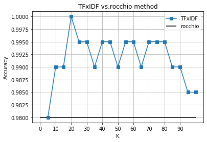

```python
x = list(range(5, 101, 5))
plt.plot(x, tfidf, label='TFxIDF', marker="s")
plt.hlines(final, 0, 100)
plt.title("TFxIDF vs.rocchio method")
plt.xlabel("K")
plt.xticks(range(0,100,10))
plt.ylabel("Accuracy")
plt.legend(['TFxIDF','rocchio'], loc="upper right")
plt.grid(True)
plt.show()
```

## 2. Classification using scikit-learn

Experiment with various classifiers provided as part of the **scikit-learn(sklearn)**

### a.

```python
btable = pd.read_csv("bank_data.csv", index_col=0)
btable
```

| id | age | income | children | gender | region | married | car | savings_acct | current_acct | mortgage | pep |
| --- | --- | --- | --- | --- | --- | --- | --- | --- | --- | --- | --- |
| ID12101 | 48 | 17546.00 | 1 | FEMALE | INNER_CITY | NO | NO | NO | NO | NO | YES |
| ID12102 | 40 | 30085.10 | 3 | MALE | TOWN | YES | YES | NO | YES | YES | NO |
| ID12103 | 51 | 16575.40 | 0 | FEMALE | INNER_CITY | YES | YES | YES | YES | NO | NO |
| ID12104 | 23 | 20375.40 | 3 | FEMALE | TOWN | YES | NO | NO | YES | NO | NO |
| ID12105 | 57 | 50576.30 | 0 | FEMALE | RURAL | YES | NO | YES | NO | NO | NO |
| ... | ... | ... | ... | ... | ... | ... | ... | ... | ... | ... | ... |
| ID12696 | 61 | 47025.00 | 2 | FEMALE | INNER_CITY | NO | YES | YES | YES | YES | NO |
| ID12697 | 30 | 9672.25 | 0 | FEMALE | INNER_CITY | YES | YES | YES | YES | NO | NO |
| ID12698 | 31 | 15976.30 | 0 | FEMALE | TOWN | YES | YES | YES | NO | NO | YES |
| ID12699 | 29 | 14711.80 | 0 | MALE | INNER_CITY | YES | NO | YES | NO | YES | NO |
| ID12700 | 38 | 26671.60 | 0 | MALE | TOWN | NO | YES | NO | YES | YES | YES |

600 rows × 11 columns

```python
btable.head()
```

| id | age | income | children | gender | region | married | car | savings_acct | current_acct | mortgage | pep |
| --- | --- | --- | --- | --- | --- | --- | --- | --- | --- | --- | --- |
| ID12101 | 48 | 17546.0 | 1 | FEMALE | INNER_CITY | NO | NO | NO | NO | NO | YES |
| ID12102 | 40 | 30085.1 | 3 | MALE | TOWN | YES | YES | NO | YES | YES | NO |
| ID12103 | 51 | 16575.4 | 0 | FEMALE | INNER_CITY | YES | YES | YES | YES | NO | NO |
| ID12104 | 23 | 20375.4 | 3 | FEMALE | TOWN | YES | NO | NO | YES | NO | NO |
| ID12105 | 57 | 50576.3 | 0 | FEMALE | RURAL | YES | NO | YES | NO | NO | NO |

```python
b_records = btable[['age','income','children','gender','region','married','savings_acct','current_acct','mortgage']]
b_records.head()
```

| id | age | income | children | gender | region | married | savings_acct | current_acct | mortgage |
| --- | --- | --- | --- | --- | --- | --- | --- | --- | --- |
| ID12101 | 48 | 17546.0 | 1 | FEMALE | INNER_CITY | NO | NO | NO | NO |
| ID12102 | 40 | 30085.1 | 3 | MALE | TOWN | YES | NO | YES | YES |
| ID12103 | 51 | 16575.4 | 0 | FEMALE | INNER_CITY | YES | YES | YES | NO |
| ID12104 | 23 | 20375.4 | 3 | FEMALE | TOWN | YES | NO | YES | NO |
| ID12105 | 57 | 50576.3 | 0 | FEMALE | RURAL | YES | YES | NO | NO |

```python
b_target = btable.pep
b_target.head()
```

```
id
ID12101    YES
ID12102     NO
ID12103     NO
ID12104     NO
ID12105     NO
Name: pep, dtype: object
```

**Create dummy variables:**

```python
b_matrix = pd.get_dummies(b_records[['age','income','children','gender','region','married','savings_acct','current_acct','mortgage']])
b_matrix.head(10)
```

| id | age | income | children | gender_FEMALE | gender_MALE | region_INNER_CITY | region_RURAL | region_SUBURBAN | region_TOWN | married_NO | married_YES | savings_acct_NO | savings_acct_YES | current_acct_NO | current_acct_YES | mortgage_NO | mortgage_YES |
| --- | --- | --- | --- | --- | --- | --- | --- | --- | --- | --- | --- | --- | --- | --- | --- | --- | --- |
| ID12101 | 48 | 17546.00 | 1 | 1 | 0 | 1 | 0 | 0 | 0 | 1 | 0 | 1 | 0 | 1 | 0 | 1 | 0 |
| ID12102 | 40 | 30085.10 | 3 | 0 | 1 | 0 | 0 | 0 | 1 | 0 | 1 | 1 | 0 | 0 | 1 | 0 | 1 |
| ID12103 | 51 | 16575.40 | 0 | 1 | 0 | 1 | 0 | 0 | 0 | 0 | 1 | 0 | 1 | 0 | 1 | 1 | 0 |
| ID12104 | 23 | 20375.40 | 3 | 1 | 0 | 0 | 0 | 0 | 1 | 0 | 1 | 1 | 0 | 0 | 1 | 1 | 0 |
| ID12105 | 57 | 50576.30 | 0 | 1 | 0 | 0 | 1 | 0 | 0 | 0 | 1 | 0 | 1 | 1 | 0 | 1 | 0 |
| ID12106 | 57 | 37869.60 | 2 | 1 | 0 | 0 | 0 | 0 | 1 | 0 | 1 | 0 | 1 | 0 | 1 | 1 | 0 |
| ID12107 | 22 | 8877.07 | 0 | 0 | 1 | 0 | 1 | 0 | 0 | 1 | 0 | 1 | 0 | 0 | 1 | 1 | 0 |
| ID12108 | 58 | 24946.60 | 0 | 0 | 1 | 0 | 0 | 0 | 1 | 0 | 1 | 0 | 1 | 0 | 1 | 1 | 0 |
| ID12109 | 37 | 25304.30 | 2 | 1 | 0 | 0 | 0 | 1 | 0 | 0 | 1 | 1 | 0 | 1 | 0 | 1 | 0 |
| ID12110 | 54 | 24212.10 | 2 | 0 | 1 | 0 | 0 | 0 | 1 | 0 | 1 | 0 | 1 | 0 | 1 | 1 | 0 |

**Use the 'train_test-split' module of 'slearn.cross_validation':**

- 'test_size=0.2' means that test size is 20% so training size will be 80%.
- 'random-state=33' means whenever I run again, it will shows same random data.

```python
from sklearn.model_selection import train_test_split
b_train, b_test, b_target_train, b_target_test = train_test_split(b_matrix, b_target, test_size=0.2, random_state=33)
print(b_test.shape)
b_test[0:5]
```

```
(120, 17)
```

| id | age | income | children | gender_FEMALE | gender_MALE | region_INNER_CITY | region_RURAL | region_SUBURBAN | region_TOWN | married_NO | married_YES | savings_acct_NO | savings_acct_YES | current_acct_NO | current_acct_YES | mortgage_NO | mortgage_YES |
| --- | --- | --- | --- | --- | --- | --- | --- | --- | --- | --- | --- | --- | --- | --- | --- | --- | --- |
| ID12557 | 32 | 13267.6 | 0 | 1 | 0 | 0 | 0 | 0 | 1 | 0 | 1 | 0 | 1 | 0 | 1 | 0 | 1 |
| ID12467 | 59 | 29866.9 | 1 | 1 | 0 | 1 | 0 | 0 | 0 | 1 | 0 | 1 | 0 | 0 | 1 | 1 | 0 |
| ID12232 | 61 | 41609.5 | 3 | 0 | 1 | 0 | 1 | 0 | 0 | 0 | 1 | 0 | 1 | 0 | 1 | 0 | 1 |
| ID12549 | 53 | 48971.6 | 3 | 0 | 1 | 0 | 1 | 0 | 0 | 0 | 1 | 0 | 1 | 1 | 0 | 1 | 0 |
| ID12438 | 65 | 38080.9 | 1 | 0 | 1 | 1 | 0 | 0 | 0 | 0 | 1 | 0 | 1 | 1 | 0 | 0 | 1 |

```python
print(b_train.shape)
b_train[0:5]
```

```
(480, 17)
```

| id | age | income | children | gender_FEMALE | gender_MALE | region_INNER_CITY | region_RURAL | region_SUBURBAN | region_TOWN | married_NO | married_YES | savings_acct_NO | savings_acct_YES | current_acct_NO | current_acct_YES | mortgage_NO | mortgage_YES |
| --- | --- | --- | --- | --- | --- | --- | --- | --- | --- | --- | --- | --- | --- | --- | --- | --- | --- |
| ID12482 | 46 | 32583.5 | 2 | 1 | 0 | 1 | 0 | 0 | 0 | 0 | 1 | 0 | 1 | 0 | 1 | 1 | 0 |
| ID12105 | 57 | 50576.3 | 0 | 1 | 0 | 0 | 1 | 0 | 0 | 0 | 1 | 0 | 1 | 1 | 0 | 1 | 0 |
| ID12187 | 25 | 15525.0 | 0 | 1 | 0 | 1 | 0 | 0 | 0 | 0 | 1 | 0 | 1 | 0 | 1 | 1 | 0 |
| ID12184 | 35 | 16394.4 | 1 | 0 | 1 | 1 | 0 | 0 | 0 | 0 | 1 | 0 | 1 | 0 | 1 | 1 | 0 |
| ID12624 | 34 | 16291.0 | 0 | 1 | 0 | 0 | 0 | 0 | 1 | 0 | 1 | 0 | 1 | 1 | 0 | 0 | 1 |

### b.

First, normalize so that the values are between 0 and 1

```python
from sklearn import preprocessing
```

```python
min_max_scaler = preprocessing.MinMaxScaler().fit(b_train)

b_train_norm = min_max_scaler.transform(b_train) # returns numpy array
b_train_norm = pd.DataFrame(b_train_norm, columns = b_train.columns, index = b_train.index)

b_test_norm = min_max_scaler.transform(b_test)
b_test_norm = pd.DataFrame(b_test_norm, columns = b_test.columns, index = b_test.index)
```

```python
b_train_norm.head()
```

| id | age | income | children | gender_FEMALE | gender_MALE | region_INNER_CITY | region_RURAL | region_SUBURBAN | region_TOWN | married_NO | married_YES | savings_acct_NO | savings_acct_YES | current_acct_NO | current_acct_YES | mortgage_NO | mortgage_YES |
| --- | --- | --- | --- | --- | --- | --- | --- | --- | --- | --- | --- | --- | --- | --- | --- | --- | --- |
| ID12482 | 0.57 | 0.46 | 0.67 | 1.0 | 0.0 | 1.0 | 0.0 | 0.0 | 0.0 | 0.0 | 1.0 | 0.0 | 1.0 | 0.0 | 1.0 | 1.0 | 0.0 |
| ID12105 | 0.80 | 0.78 | 0.00 | 1.0 | 0.0 | 0.0 | 1.0 | 0.0 | 0.0 | 0.0 | 1.0 | 0.0 | 1.0 | 1.0 | 0.0 | 1.0 | 0.0 |
| ID12187 | 0.14 | 0.16 | 0.00 | 1.0 | 0.0 | 1.0 | 0.0 | 0.0 | 0.0 | 0.0 | 1.0 | 0.0 | 1.0 | 0.0 | 1.0 | 1.0 | 0.0 |
| ID12184 | 0.35 | 0.18 | 0.33 | 0.0 | 1.0 | 1.0 | 0.0 | 0.0 | 0.0 | 0.0 | 1.0 | 0.0 | 1.0 | 0.0 | 1.0 | 1.0 | 0.0 |
| ID12624 | 0.33 | 0.18 | 0.00 | 1.0 | 0.0 | 0.0 | 0.0 | 0.0 | 1.0 | 0.0 | 1.0 | 0.0 | 1.0 | 1.0 | 0.0 | 0.0 | 1.0 |

```python
b_test_norm.head()
```

| id | age | income | children | gender_FEMALE | gender_MALE | region_INNER_CITY | region_RURAL | region_SUBURBAN | region_TOWN | married_NO | married_YES | savings_acct_NO | savings_acct_YES | current_acct_NO | current_acct_YES | mortgage_NO | mortgage_YES |
| --- | --- | --- | --- | --- | --- | --- | --- | --- | --- | --- | --- | --- | --- | --- | --- | --- | --- |
| ID12557 | 0.29 | 0.12 | 0.00 | 1.0 | 0.0 | 0.0 | 0.0 | 0.0 | 1.0 | 0.0 | 1.0 | 0.0 | 1.0 | 0.0 | 1.0 | 0.0 | 1.0 |
| ID12467 | 0.84 | 0.41 | 0.33 | 1.0 | 0.0 | 1.0 | 0.0 | 0.0 | 0.0 | 1.0 | 0.0 | 1.0 | 0.0 | 0.0 | 1.0 | 1.0 | 0.0 |
| ID12232 | 0.88 | 0.62 | 1.00 | 0.0 | 1.0 | 0.0 | 1.0 | 0.0 | 0.0 | 0.0 | 1.0 | 0.0 | 1.0 | 0.0 | 1.0 | 0.0 | 1.0 |
| ID12549 | 0.71 | 0.75 | 1.00 | 0.0 | 1.0 | 0.0 | 1.0 | 0.0 | 0.0 | 0.0 | 1.0 | 0.0 | 1.0 | 1.0 | 0.0 | 1.0 | 0.0 |
| ID12438 | 0.96 | 0.56 | 0.33 | 0.0 | 1.0 | 1.0 | 0.0 | 0.0 | 0.0 | 0.0 | 1.0 | 0.0 | 1.0 | 1.0 | 0.0 | 0.0 | 1.0 |

**K nearest neigoborhoods, decision tree, naive_bayes:**

```python
from sklearn import neighbors, tree, naive_bayes
```

**KNN classifier:**

- **with distance weighting**

```python
# choose K = 5
n_neigh = 5

# create knn object
knn = neighbors.KNeighborsClassifier(n_neigh, weights='distance') # similarity of distance

# to fit the training data, labels(training portion)
knn.fit(b_train_norm, b_target_train)
```

```
KNeighborsClassifier(algorithm='auto', leaf_size=30, metric='minkowski',
                     metric_params=None, n_jobs=None, n_neighbors=5, p=2,
                     weights='distance')
```

> one of default setting, metric='minkowski' means euclidean distance

**Using predict function and predict class labels:**

```python
knnpreds_test = knn.predict(b_test_norm)
```

```python
print(knnpreds_test)
```

```
['YES' 'YES' 'NO' 'NO' 'YES' 'YES' 'YES' 'NO' 'NO' 'YES' 'NO' 'YES' 'YES' 'NO' 'NO' 'NO' 'YES' 'YES' 'YES' 'NO' 'YES'
 'YES' 'NO' 'NO' 'YES' 'NO' 'YES' 'YES' 'NO' 'YES' 'NO' 'NO' 'NO' 'YES' 'YES' 'YES' 'NO' 'YES' 'NO' 'NO' 'YES' 'YES'
 'YES' 'NO' 'YES' 'YES' 'YES' 'NO' 'NO' 'YES' 'NO' 'YES' 'YES' 'YES' 'YES' 'YES' 'NO' 'YES' 'YES' 'NO' 'NO' 'NO' 'NO'
 'YES' 'NO' 'NO' 'NO' 'NO' 'NO' 'YES' 'YES' 'NO' 'YES' 'NO' 'NO' 'NO' 'NO' 'YES' 'YES' 'NO' 'YES' 'YES' 'YES' 'YES'
 'NO' 'NO' 'NO' 'NO' 'NO' 'YES' 'YES' 'NO' 'NO' 'NO' 'NO' 'NO' 'NO' 'NO' 'NO' 'NO' 'NO' 'NO' 'YES' 'YES' 'NO' 'NO' 'NO'
 'NO' 'YES' 'NO' 'YES' 'YES' 'NO' 'YES' 'NO' 'NO' 'NO' 'NO' 'NO' 'YES']
```

**Evaluate classifier accuracy using scikit-learn:**

```python
from sklearn.metrics import classification_report
```

```python
print(classification_report(b_target_test, knnpreds_test)) # compare actual label and predicted label
```

```
              precision    recall  f1-score   support

          NO       0.70      0.70      0.70        66
         YES       0.63      0.63      0.63        54

    accuracy                           0.67       120
   macro avg       0.66      0.66      0.66       120
weighted avg       0.67      0.67      0.67       120
```

**Confusion_matrix:**

> true positive, true negative, false positive, false negative

```python
from sklearn.metrics import confusion_matrix
```

```python
knncm = confusion_matrix(b_target_test, knnpreds_test)
print(knncm)
```

```
[[46 20]
 [20 34]]
```

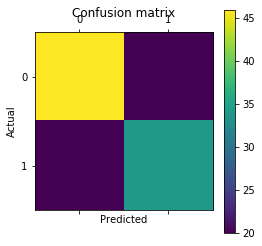

```python
import pylab as plt
%matplotlib inline

plt.matshow(knncm)
plt.title('Confusion matrix')
plt.colorbar()
plt.ylabel('Actual')
plt.xlabel('Predicted')
plt.show()
```

```python
print(knn.score(b_test_norm, b_target_test)) # overall accuracy(avg) of (test instance and test label)
```

```
0.6666666666666666
```

```python
print(knn.score(b_train_norm, b_target_train)) # compare to the performance on the training data itself
```

```
1.0
```

```python
# check the value from K=1 to K=11 with distance weighting
for n_neigh in range(1, 12):
    knn = neighbors.KNeighborsClassifier(n_neigh, weights='distance')
    knn.fit(b_train_norm, b_target_train)
    train_score = knn.score(b_train_norm, b_target_train)
    test_score = knn.score(b_test_norm, b_target_test)
    print("K = {}".format(n_neigh))
    print("Train score: {} , Test score: {}\n".format(train_score, test_score))
```

```
K = 1
Train score: 1.0 , Test score: 0.6583333333333333

K = 2
Train score: 1.0 , Test score: 0.6583333333333333

K = 3
Train score: 1.0 , Test score: 0.65

K = 4
Train score: 1.0 , Test score: 0.6166666666666667

K = 5
Train score: 1.0 , Test score: 0.6666666666666666

K = 6
Train score: 1.0 , Test score: 0.6416666666666667

K = 7
Train score: 1.0 , Test score: 0.675

K = 8
Train score: 1.0 , Test score: 0.6666666666666666

K = 9
Train score: 1.0 , Test score: 0.6666666666666666

K = 10
Train score: 1.0 , Test score: 0.6666666666666666

K = 11
Train score: 1.0 , Test score: 0.6416666666666667
```

```python
# choose K = 7
n_neigh = 7

knn = neighbors.KNeighborsClassifier(n_neigh, weights='distance')
knn.fit(b_train_norm, b_target_train)
```

```
KNeighborsClassifier(algorithm='auto', leaf_size=30, metric='minkowski',
                     metric_params=None, n_jobs=None, n_neighbors=7, p=2,
                     weights='distance')
```

```python
knnpreds_test = knn.predict(b_test_norm)
```

```python
print(knnpreds_test)
```

```
['YES' 'YES' 'YES' 'NO' 'YES' 'YES' 'YES' 'NO' 'NO' 'YES' 'NO' 'YES' 'YES' 'NO' 'NO' 'NO' 'YES' 'NO' 'YES' 'NO' 'YES'
 'YES' 'NO' 'NO' 'YES' 'NO' 'YES' 'YES' 'YES' 'YES' 'NO' 'NO' 'NO' 'NO' 'YES' 'YES' 'NO' 'YES' 'NO' 'YES' 'NO' 'YES'
 'YES' 'NO' 'YES' 'YES' 'YES' 'NO' 'NO' 'YES' 'NO' 'YES' 'YES' 'YES' 'YES' 'YES' 'NO' 'YES' 'NO' 'NO' 'YES' 'NO' 'NO'
 'YES' 'YES' 'NO' 'NO' 'NO' 'NO' 'YES' 'YES' 'YES' 'NO' 'NO' 'NO' 'NO' 'NO' 'YES' 'YES' 'NO' 'YES' 'YES' 'YES' 'YES'
 'NO' 'NO' 'YES' 'NO' 'NO' 'YES' 'NO' 'NO' 'NO' 'NO' 'NO' 'NO' 'NO' 'NO' 'NO' 'NO' 'NO' 'NO' 'YES' 'YES' 'NO' 'NO' 'NO'
 'NO' 'YES' 'NO' 'YES' 'YES' 'NO' 'YES' 'NO' 'NO' 'NO' 'NO' 'NO' 'YES']
```

```python
print(classification_report(b_target_test, knnpreds_test))
```

```
              precision    recall  f1-score   support

          NO       0.71      0.70      0.70        66
         YES       0.64      0.65      0.64        54

    accuracy                           0.68       120
   macro avg       0.67      0.67      0.67       120
weighted avg       0.68      0.68      0.68       120
```

```python
knncm = confusion_matrix(b_target_test, knnpreds_test)
print(knncm)
```

```
[[46 20]
 [19 35]]
```

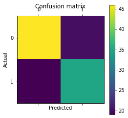

```python
plt.matshow(knncm)
plt.title('Confusion matrix')
plt.colorbar()
plt.ylabel('Actual')
plt.xlabel('Predicted')
plt.show()
```

```python
train_score = knn.score(b_train_norm, b_target_train)
test_score = knn.score(b_test_norm, b_target_test)
print("Train score: {} , Test score: {}\n".format(train_score, test_score))
```

```
Train score: 1.0 , Test score: 0.675
```

- **without distance weighting**

```python
# check the value from K=1 to K=11 without distance weighting
for n_neigh in range(1, 12):
    knn = neighbors.KNeighborsClassifier(n_neigh)
    knn.fit(b_train_norm, b_target_train)
    train_score = knn.score(b_train_norm, b_target_train)
    test_score = knn.score(b_test_norm, b_target_test)
    print("K = {}".format(n_neigh))
    print("Train score: {} , Test score: {}\n".format(train_score, test_score))
```

```
K = 1
Train score: 1.0 , Test score: 0.6583333333333333

K = 2
Train score: 0.8625 , Test score: 0.6583333333333333

K = 3
Train score: 0.825 , Test score: 0.625

K = 4
Train score: 0.7895833333333333 , Test score: 0.6166666666666667

K = 5
Train score: 0.78125 , Test score: 0.65

K = 6
Train score: 0.7625 , Test score: 0.6916666666666667

K = 7
Train score: 0.7541666666666667 , Test score: 0.6666666666666666

K = 8
Train score: 0.7333333333333333 , Test score: 0.6333333333333333

K = 9
Train score: 0.7541666666666667 , Test score: 0.6333333333333333

K = 10
Train score: 0.7479166666666667 , Test score: 0.5916666666666667

K = 11
Train score: 0.76875 , Test score: 0.6083333333333333
```

```python
# choose K = 6
n_neigh = 6

knn = neighbors.KNeighborsClassifier(n_neigh)
knn.fit(b_train_norm, b_target_train)
```

```
KNeighborsClassifier(algorithm='auto', leaf_size=30, metric='minkowski',
                     metric_params=None, n_jobs=None, n_neighbors=6, p=2,
                     weights='uniform')
```

```python
knnpreds_test = knn.predict(b_test_norm)
```

```python
print(knnpreds_test)
```

```
['NO' 'YES' 'NO' 'NO' 'NO' 'YES' 'NO' 'NO' 'NO' 'YES' 'NO' 'YES' 'NO' 'NO' 'NO' 'NO' 'YES' 'NO' 'YES' 'NO' 'YES' 'YES'
 'NO' 'NO' 'YES' 'NO' 'YES' 'YES' 'NO' 'YES' 'NO' 'NO' 'NO' 'NO' 'NO' 'YES' 'NO' 'YES' 'NO' 'NO' 'NO' 'NO' 'YES' 'NO'
 'YES' 'NO' 'YES' 'NO' 'NO' 'YES' 'NO' 'YES' 'YES' 'NO' 'YES' 'YES' 'NO' 'YES' 'NO' 'NO' 'NO' 'NO' 'NO' 'NO' 'NO' 'NO'
 'NO' 'NO' 'NO' 'YES' 'YES' 'YES' 'NO' 'NO' 'NO' 'NO' 'NO' 'YES' 'YES' 'NO' 'NO' 'YES' 'YES' 'NO' 'NO' 'NO' 'NO' 'NO'
 'NO' 'YES' 'NO' 'NO' 'NO' 'NO' 'NO' 'NO' 'NO' 'NO' 'NO' 'NO' 'NO' 'NO' 'YES' 'YES' 'NO' 'NO' 'NO' 'NO' 'YES' 'NO'
 'YES' 'YES' 'NO' 'YES' 'NO' 'NO' 'NO' 'NO' 'NO' 'NO']
```

```python
print(classification_report(b_target_test, knnpreds_test))
```

```
              precision    recall  f1-score   support

          NO       0.67      0.85      0.75        66
         YES       0.73      0.50      0.59        54

    accuracy                           0.69       120
   macro avg       0.70      0.67      0.67       120
weighted avg       0.70      0.69      0.68       120
```

```python
knncm = confusion_matrix(b_target_test, knnpreds_test)
print(knncm)
```

```
[[56 10]
 [27 27]]
```

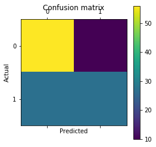

```python
plt.matshow(knncm)
plt.title('Confusion matrix')
plt.colorbar()
plt.ylabel('Actual')
plt.xlabel('Predicted')
plt.show()
```

```python
train_score = knn.score(b_train_norm, b_target_train)
test_score = knn.score(b_test_norm, b_target_test)
print("Train score: {} , Test score: {}\n".format(train_score, test_score))
```

```
Train score: 0.7625 , Test score: 0.6916666666666667
```

**Provide a short discussion on what parameters worked best as well as your final results:**  
It seems that hyperparameters affect our result. When I ran it with distance weighting, I got the train_score: 1.0 and the test_score: 0.675. It gets 100% accuracy on the train_data but it gets worse accuracy on the test_data. We can say that this is 'overfitting' in this case. On the other hand, when I ran it without distance weighting, I got the train_score: 0.7625 and the test_score: 0.6916666666666667. The gap of the training and the test accuracy is less than with distance weighting. Therefore, we should experiment with different hyperparameters to improve our accuracy and check the 'overfitting' and 'underfitting'.

### C.

Using the **non-normalized** traininhg and test data, perform classification using scikit-learn's decision tree classifier(using the default parameters)

```python
# using default parameters
treeclf = tree.DecisionTreeClassifier()
```

```python
treeclf = treeclf.fit(b_train, b_target_train) # non-normalized training data
```

```python
treepreds_test = treeclf.predict(b_test)
print(treepreds_test)
```

```
['NO' 'YES' 'NO' 'YES' 'YES' 'YES' 'YES' 'NO' 'YES' 'NO' 'NO' 'YES' 'NO' 'NO' 'NO' 'NO' 'NO' 'NO' 'YES' 'NO' 'YES' 'NO'
 'NO' 'NO' 'YES' 'NO' 'YES' 'YES' 'NO' 'YES' 'NO' 'NO' 'NO' 'YES' 'NO' 'YES' 'NO' 'YES' 'NO' 'YES' 'YES' 'NO' 'NO' 'NO'
 'YES' 'NO' 'NO' 'YES' 'NO' 'YES' 'YES' 'YES' 'YES' 'YES' 'NO' 'YES' 'YES' 'YES' 'NO' 'NO' 'YES' 'NO' 'YES' 'YES' 'YES'
 'YES' 'NO' 'NO' 'YES' 'YES' 'YES' 'NO' 'NO' 'YES' 'NO' 'NO' 'NO' 'NO' 'YES' 'NO' 'NO' 'YES' 'YES' 'NO' 'NO' 'YES' 'NO'
 'NO' 'YES' 'YES' 'NO' 'NO' 'NO' 'NO' 'YES' 'NO' 'NO' 'NO' 'NO' 'NO' 'NO' 'NO' 'YES' 'YES' 'NO' 'YES' 'YES' 'NO' 'YES'
 'NO' 'YES' 'NO' 'NO' 'YES' 'NO' 'NO' 'NO' 'NO' 'NO' 'NO']
```

```python
print(treeclf.score(b_test, b_target_test))
```

```
0.825
```

```python
print(treeclf.score(b_train, b_target_train))
```

```
1.0
```

```python
print(classification_report(b_target_test, treepreds_test))
```

```
              precision    recall  f1-score   support

          NO       0.83      0.86      0.84        66
         YES       0.82      0.78      0.80        54

    accuracy                           0.82       120
   macro avg       0.82      0.82      0.82       120
weighted avg       0.82      0.82      0.82       120
```

```python
treecm = confusion_matrix(b_target_test, treepreds_test)
print(treecm)
```

```
[[57  9]
 [12 42]]
```

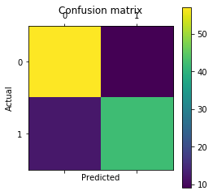

```python
plt.matshow(treecm)
plt.title('Confusion matrix')
plt.colorbar()
plt.ylabel('Actual')
plt.xlabel('Predicted')
plt.show()
```

```python
train_score = treeclf.score(b_train, b_target_train)
test_score = treeclf.score(b_test, b_target_test)
print("Train score: {} , Test score: {}\n".format(train_score, test_score))
```

```
Train score: 1.0 , Test score: 0.825
```

**What does the comparison tell you in terms of bias-variance trade off?** Bias are assumptions made by a model to learn. Models with high bias give little attention to the training data and make very simple model so it could lead to high errors on training and test data. Variance tells us how spread out our data is. Models with high variance give lots of attention to training data so it performs well on training data but it is the opposite on test data. Decision trees can be the models that have large number of parameters but then it’s going to have high variance and low bias. I got the results where train_score: 1.0 and it shows 100% accuracy on the training data. This exactly matches with the high variance and low bias case. To avoid overfitting or underfitting we must find a good balance.

### d.

Create another decision tree model(non-normalized training data) using "**entropy**" as the selection creteria, **min_samples_split**=10, and **max_depth**=5.

```python
# using criterion=entropy, min_samples_split=10, and max_depth=5
treeclf = tree.DecisionTreeClassifier(criterion='entropy', min_samples_split=10, max_depth=5)
```

```python
treeclf = treeclf.fit(b_train, b_target_train) # non-normalized training data
```

```python
treepreds_test = treeclf.predict(b_test)
print(treepreds_test)
```

```
['NO' 'YES' 'NO' 'YES' 'YES' 'NO' 'YES' 'NO' 'YES' 'NO' 'NO' 'YES' 'NO' 'NO' 'NO' 'NO' 'NO' 'NO' 'YES' 'NO' 'YES' 'YES'
 'NO' 'NO' 'YES' 'NO' 'YES' 'YES' 'NO' 'YES' 'NO' 'NO' 'NO' 'YES' 'NO' 'NO' 'NO' 'YES' 'NO' 'YES' 'YES' 'NO' 'NO' 'NO'
 'YES' 'NO' 'NO' 'NO' 'NO' 'NO' 'YES' 'YES' 'YES' 'YES' 'YES' 'YES' 'YES' 'YES' 'NO' 'NO' 'YES' 'NO' 'YES' 'YES' 'YES'
 'NO' 'NO' 'NO' 'YES' 'NO' 'YES' 'NO' 'NO' 'YES' 'NO' 'NO' 'NO' 'NO' 'YES' 'NO' 'NO' 'NO' 'YES' 'NO' 'NO' 'YES' 'YES'
 'NO' 'YES' 'NO' 'NO' 'NO' 'NO' 'NO' 'YES' 'NO' 'NO' 'NO' 'NO' 'NO' 'NO' 'NO' 'YES' 'YES' 'NO' 'NO' 'NO' 'NO' 'YES'
 'NO' 'NO' 'NO' 'NO' 'NO' 'NO' 'NO' 'NO' 'NO' 'NO' 'YES']
```

```python
print(treeclf.score(b_test, b_target_test))
```

```
0.7916666666666666
```

```python
print("Accuracy on Training: ", treeclf.score(b_train, b_target_train))
```

```
Accuracy on Training:  0.8666666666666667
```

```python
print(classification_report(b_target_test, treepreds_test))
```

```
              precision    recall  f1-score   support

          NO       0.77      0.89      0.83        66
         YES       0.84      0.67      0.74        54

    accuracy                           0.79       120
   macro avg       0.80      0.78      0.78       120
weighted avg       0.80      0.79      0.79       120
```

```python
treecm = confusion_matrix(b_target_test, treepreds_test)
print(treecm)
```

```
[[59  7]
 [18 36]]
```

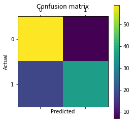

```python
plt.matshow(treecm)
plt.title('Confusion matrix')
plt.colorbar()
plt.ylabel('Actual')
plt.xlabel('Predicted')
plt.show()
```

```python
from sklearn.tree import export_graphviz

from IPython.display import SVG
from graphviz import Source
from IPython.display import display

tree = export_graphviz(treeclf, out_file=None, feature_names=b_train.columns, class_names=['No','Yes'])
graph = Source(tree)
```

```python
display(SVG(graph.pipe(format='svg')))
```

[figure not shown]

```python
tree = export_graphviz(treeclf, out_file='tree.dot', feature_names=b_train.columns, class_names=['No','Yes'], filled=True)

import graphviz

with open("tree.dot") as f:
    dot_graph = f.read()
graphviz.Source(dot_graph, format="png")
```

[figure not shown]

```python
system(dot -Tpng tree.dot -o dtree.png)
```

```
[]
```

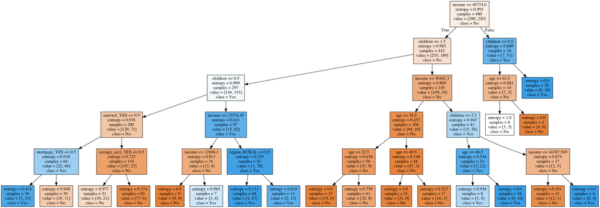

```python
from IPython.display import Image
Image(filename='dtree.png', width=900)
```

## 3. Data Analysis and Predictive Modeling on Census data

### a. Preprocessing and data analysis:

- **Examine the data for missing values. In case of categorical attributes, remove instances with missing values. In the case of numeric attributes, impute and fill-in the missing values using the attribute mean.**

```python
am_table = pd.read_csv("adult-modified.csv", na_values=["?"])
am_table
```

|  | age | workclass | education | marital-status | race | sex | hours-per-week | income |
| --- | --- | --- | --- | --- | --- | --- | --- | --- |
| 0 | 39.0 | Public | 13 | Single | White | Male | 40 | <=50K |
| 1 | 50.0 | Self-emp | 13 | Married | White | Male | 13 | <=50K |
| 2 | 38.0 | Private | 9 | Single | White | Male | 40 | <=50K |
| 3 | 53.0 | Private | 7 | Married | Black | Male | 40 | <=50K |
| 4 | 28.0 | Private | 13 | Married | Black | Female | 40 | <=50K |
| ... | ... | ... | ... | ... | ... | ... | ... | ... |
| 9995 | 38.0 | Private | 10 | Married | White | Male | 60 | >50K |
| 9996 | 25.0 | Private | 9 | Single | White | Female | 8 | <=50K |
| 9997 | 21.0 | Private | 10 | Single | Black | Male | 40 | <=50K |
| 9998 | NaN | Private | 2 | Married | White | Male | 53 | <=50K |
| 9999 | 39.0 | Private | 10 | Single | White | Female | 40 | <=50K |

10000 rows × 8 columns

```python
# determine all the attributes
am_table.info()
```

```
<class 'pandas.core.frame.DataFrame'>
RangeIndex: 10000 entries, 0 to 9999
Data columns (total 8 columns):
 #   Column          Non-Null Count  Dtype
---  ------          --------------  -----
 0   age             9802 non-null   float64
 1   workclass       9412 non-null   object
 2   education       10000 non-null  int64
 3   marital-status  10000 non-null  object
 4   race            10000 non-null  object
 5   sex             10000 non-null  object
 6   hours-per-week  10000 non-null  int64
 7   income          10000 non-null  object
dtypes: float64(1), int64(2), object(5)
memory usage: 625.1+ KB
```

```python
# Check all the instances that contain a missing value

am_table[am_table.isnull().any(axis=1)]
```

|  | age | workclass | education | marital-status | race | sex | hours-per-week | income |
| --- | --- | --- | --- | --- | --- | --- | --- | --- |
| 19 | NaN | Self-emp | 14 | Single | White | Female | 45 | >50K |
| 27 | NaN | NaN | 10 | Married | Asian | Male | 60 | >50K |
| 40 | NaN | Private | 5 | Married | White | Male | 43 | <=50K |
| 61 | 32.0 | NaN | 4 | Married | White | Male | 40 | <=50K |
| 65 | NaN | Private | 9 | Married | White | Male | 40 | <=50K |
| ... | ... | ... | ... | ... | ... | ... | ... | ... |
| 9965 | NaN | Private | 10 | Married | Amer-Indian | Female | 40 | <=50K |
| 9966 | NaN | Private | 13 | Married | White | Male | 50 | >50K |
| 9987 | 67.0 | NaN | 4 | Married | White | Male | 40 | <=50K |
| 9993 | NaN | Private | 9 | Married | White | Female | 15 | <=50K |
| 9998 | NaN | Private | 2 | Married | White | Male | 53 | <=50K |

777 rows × 8 columns

```python
# fill-in the missing values using the attribute mean
age_mean = am_table.age.mean()
am_table.age.fillna(age_mean, axis=0, inplace=True)
am_table
```

|  | age | workclass | education | marital-status | race | sex | hours-per-week | income |
| --- | --- | --- | --- | --- | --- | --- | --- | --- |
| 0 | 39.00 | Public | 13 | Single | White | Male | 40 | <=50K |
| 1 | 50.00 | Self-emp | 13 | Married | White | Male | 13 | <=50K |
| 2 | 38.00 | Private | 9 | Single | White | Male | 40 | <=50K |
| 3 | 53.00 | Private | 7 | Married | Black | Male | 40 | <=50K |
| 4 | 28.00 | Private | 13 | Married | Black | Female | 40 | <=50K |
| ... | ... | ... | ... | ... | ... | ... | ... | ... |
| 9995 | 38.00 | Private | 10 | Married | White | Male | 60 | >50K |
| 9996 | 25.00 | Private | 9 | Single | White | Female | 8 | <=50K |
| 9997 | 21.00 | Private | 10 | Single | Black | Male | 40 | <=50K |
| 9998 | 38.45 | Private | 2 | Married | White | Male | 53 | <=50K |
| 9999 | 39.00 | Private | 10 | Single | White | Female | 40 | <=50K |

10000 rows × 8 columns

```python
# remove instance with missing values in case of categorical attributes
am_table.dropna(axis=0, inplace=True)
```

```python
# check the result
am_table.info()
```

```
<class 'pandas.core.frame.DataFrame'>
Int64Index: 9412 entries, 0 to 9999
Data columns (total 8 columns):
 #   Column          Non-Null Count  Dtype
---  ------          --------------  -----
 0   age             9412 non-null   float64
 1   workclass       9412 non-null   object
 2   education       9412 non-null   int64
 3   marital-status  9412 non-null   object
 4   race            9412 non-null   object
 5   sex             9412 non-null   object
 6   hours-per-week  9412 non-null   int64
 7   income          9412 non-null   object
dtypes: float64(1), int64(2), object(5)
memory usage: 661.8+ KB
```

- **Examine the characteristics of the attributes, including summary statistics for the attributes, histograms illustrating the distributions of numeric attributes, and bar graphs showing value counts for categorical attributes.**

```python
# Explore the general characteristics of the data

am_table.describe()
```

|  | age | education | hours-per-week |
| --- | --- | --- | --- |
| count | 9412.00 | 9412.00 | 9412.00 |
| mean | 38.37 | 10.13 | 41.08 |
| std | 12.96 | 2.54 | 11.88 |
| min | 17.00 | 1.00 | 1.00 |
| 25% | 28.00 | 9.00 | 40.00 |
| 50% | 37.00 | 10.00 | 40.00 |
| 75% | 47.00 | 13.00 | 45.00 |
| max | 90.00 | 16.00 | 99.00 |

```python
min_am = am_table[['age','education','hours-per-week']].mean()
max_am = am_table[['age','education','hours-per-week']].max()
print(min_am, max_am)
```

```
age               38.37
education         10.13
hours-per-week    41.08
dtype: float64 age               90.0
education         16.0
hours-per-week    99.0
dtype: float64
```

```python
min_max_norm = (am_table[['age','education','hours-per-week']] - min_am)/(max_am - min_am)
min_max_norm.head()
```

|  | age | education | hours-per-week |
| --- | --- | --- | --- |
| 0 | 1.23e-02 | 0.49 | -0.02 |
| 1 | 2.25e-01 | 0.49 | -0.48 |
| 2 | -7.10e-03 | -0.19 | -0.02 |
| 3 | 2.83e-01 | -0.53 | -0.02 |
| 4 | -2.01e-01 | 0.49 | -0.02 |

```python
corr_am = am_table[['age','education','hours-per-week']].corr()
corr_am
```

|  | age | education | hours-per-week |
| --- | --- | --- | --- |
| age | 1.00 | 0.03 | 0.10 |
| education | 0.03 | 1.00 | 0.14 |
| hours-per-week | 0.10 | 0.14 | 1.00 |

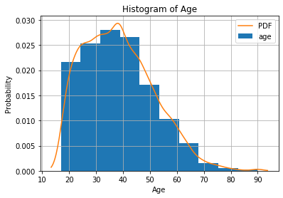

```python
# histograms (numeric attributes)

import scipy.stats as st
plt.hist(am_table['age'], density=True, bins = 10, label='age')
mn, mx = plt.xlim()
kde_xs = np.linspace(mn, mx, 300)
kde = st.gaussian_kde(am_table['age'])
plt.plot(kde_xs, kde.pdf(kde_xs), label='PDF')
plt.legend(loc='upper right')
plt.ylabel('Probability')
plt.xlabel('Age')
plt.title('Histogram of Age')
plt.grid(True)
plt.show()
```

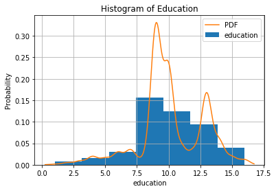

```python
plt.hist(am_table['education'], density=True, bins = 7, label='education')
mn, mx = plt.xlim()
kde_xs = np.linspace(mn, mx, 300)
kde = st.gaussian_kde(am_table['education'])
plt.plot(kde_xs, kde.pdf(kde_xs), label='PDF')
plt.legend(loc='upper right')
plt.ylabel('Probability')
plt.xlabel('education')
plt.title('Histogram of Education')
plt.grid(True)
plt.show()
```

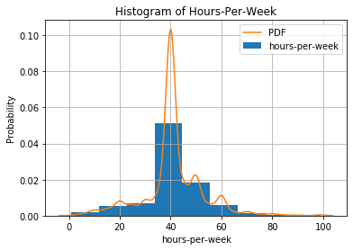

```python
plt.hist(am_table['hours-per-week'], density=True, bins = 9, label='hours-per-week')
mn, mx = plt.xlim()
kde_xs = np.linspace(mn, mx, 300)
kde = st.gaussian_kde(am_table['hours-per-week'])
plt.plot(kde_xs, kde.pdf(kde_xs), label='PDF')
plt.legend(loc='upper right')
plt.ylabel('Probability')
plt.xlabel('hours-per-week')
plt.title('Histogram of Hours-Per-Week')
plt.grid(True)
plt.show()
```

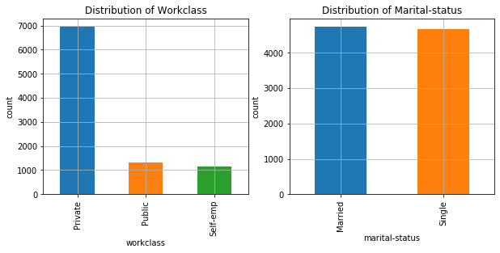

```python
# bar graph (categorical attributes)
temp1 = am_table['workclass'].value_counts()
temp2 = am_table['marital-status'].value_counts()

fig = plt.figure(figsize=(10,4))

ax1 = fig.add_subplot(121)
ax1.set_xlabel('workclass')
ax1.set_ylabel('count')
ax1.set_title('Distribution of Workclass')
temp1.plot(kind='bar', grid=True, color=['C0', 'C1', 'C2'])

ax1 = fig.add_subplot(122)
ax1.set_xlabel('marital-status')
ax1.set_ylabel('count')
ax1.set_title('Distribution of Marital-status')
temp2.plot(kind='bar', grid=True, color=['C0', 'C1'])
```

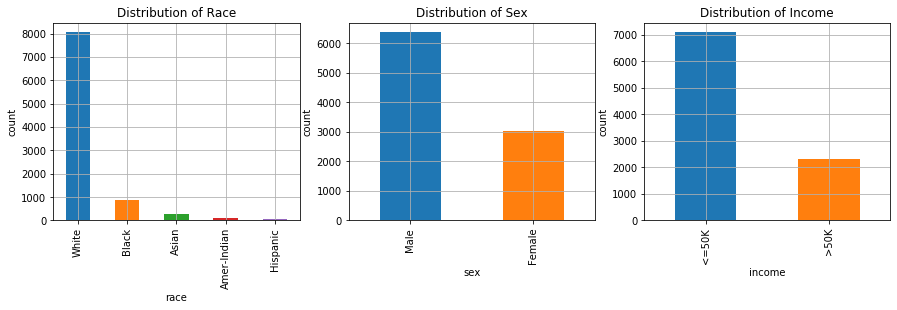

```python
temp3 = am_table['race'].value_counts()
temp4 = am_table['sex'].value_counts()
temp5 = am_table['income'].value_counts()

fig = plt.figure(figsize=(15,8))

ax1 = fig.add_subplot(231)
ax1.set_xlabel('race')
ax1.set_ylabel('count')
ax1.set_title('Distribution of Race')
temp3.plot(kind='bar', grid=True, color=['C0', 'C1', 'C2','C3','C4'])

ax1 = fig.add_subplot(232)
ax1.set_xlabel('sex')
ax1.set_ylabel('count')
ax1.set_title('Distribution of Sex')
temp4.plot(kind='bar', grid=True, color=['C0', 'C1'])

ax1 = fig.add_subplot(233)
ax1.set_xlabel('income')
ax1.set_ylabel('count')
ax1.set_title('Distribution of Income')
temp5.plot(kind='bar', grid=True, color=['C0', 'C1'])
```

- **Perform the** `cross-tabulations` **(including generateing bar charts)**

```python
# education + race
education_race = pd.crosstab(am_table['education'],am_table['race'])
education_race.T
```

| education race | 1 | 2 | 3 | 4 | 5 | 6 | 7 | 8 | 9 | 10 | 11 | 12 | 13 | 14 | 15 | 16 |
| --- | --- | --- | --- | --- | --- | --- | --- | --- | --- | --- | --- | --- | --- | --- | --- | --- |
| Amer-Indian | 0 | 0 | 0 | 5 | 0 | 8 | 4 | 0 | 35 | 26 | 5 | 4 | 5 | 0 | 0 | 0 |
| Asian | 0 | 1 | 4 | 5 | 3 | 3 | 6 | 2 | 67 | 64 | 10 | 5 | 75 | 27 | 11 | 8 |
| Black | 1 | 4 | 5 | 14 | 19 | 30 | 49 | 17 | 350 | 206 | 33 | 33 | 102 | 20 | 5 | 4 |
| Hispanic | 0 | 3 | 1 | 6 | 2 | 4 | 4 | 3 | 23 | 11 | 4 | 3 | 8 | 1 | 2 | 0 |
| White | 11 | 38 | 71 | 150 | 118 | 223 | 261 | 78 | 2590 | 1818 | 337 | 259 | 1387 | 467 | 153 | 101 |

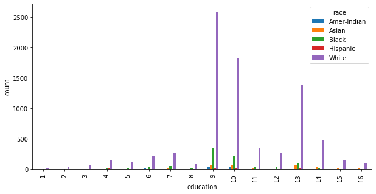

```python
p1 = education_race.plot(kind='bar', figsize=(10,5))
p1.set_ylabel('count')
plt.show(p1)
```

Education levels are concentrated in levels 9-10 regardless of race. Also, most whites have a fairly high number at education levels 9-10 and 13-14 is also somewhat high. The Black race also tends to be very similar to the previous ones, but the total number is much smaller than those of whites. Asians are also concentrated in levels 9-10 and 13-14.

```python
# work-class + income
workclass_income = pd.crosstab(am_table['workclass'],am_table['income'])
workclass_income.T
```

| workclass income | Private | Public | Self-emp |
| --- | --- | --- | --- |
| <=50K | 5443 | 925 | 725 |
| >50K | 1504 | 392 | 423 |

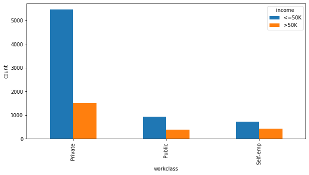

```python
p2 = workclass_income.plot(kind='bar', figsize=(10,5))
p2.set_ylabel('count')
plt.show(p2)
```

The number of high and low incomes make up a large proportion of the private work-class. However, there is a big gap between the high and low income groups in the private work-class. The self-employed work-class compared to the private work-class shows a significantly less gap in income.

```python
# work-class + race
workclass_race = pd.crosstab(am_table['workclass'],am_table['race'])
workclass_race
```

| race workclass | Amer-Indian | Asian | Black | Hispanic | White |
| --- | --- | --- | --- | --- | --- |
| Private | 65 | 204 | 664 | 64 | 5950 |
| Public | 20 | 48 | 192 | 5 | 1052 |
| Self-emp | 7 | 39 | 36 | 6 | 1060 |

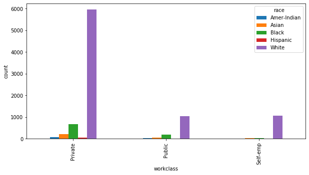

```python
p3 = workclass_race.plot(kind='bar', figsize=(10,5))
p3.set_ylabel('count')
plt.show(p3)
```

The number of white people working in the private work-class is the highest. All of the other races are also engaged the private work-class to a lesser extent. Meanwhile, in the self-employed category, Hispanic and American Indian races are hardly represented.

```python
# race + income
race_income = pd.crosstab(am_table['race'],am_table['income'])
race_income.T
```

| race income | Amer-Indian | Asian | Black | Hispanic | White |
| --- | --- | --- | --- | --- | --- |
| <=50K | 83 | 224 | 773 | 69 | 5944 |
| >50K | 9 | 67 | 119 | 6 | 2118 |

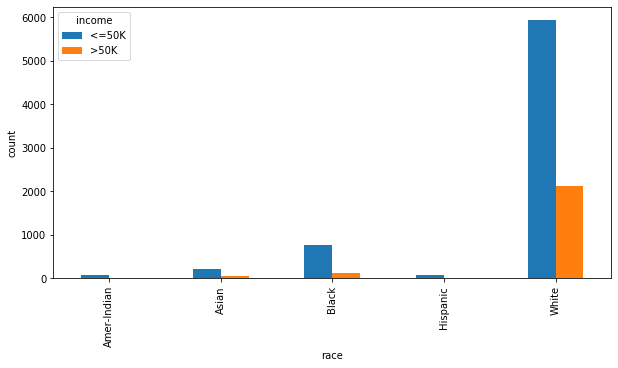

```python
p4 = race_income.plot(kind='bar', figsize=(10,5))
p4.set_ylabel('count')
plt.show(p4)
```

The White race makes up the majority of the low-income class, followed by the Black race. However, most of the high-income brackets are also occupied by whites. Hispanic and American Indians have very few numbers, in both low and high income.

```python
# percentage(race + income)
percent_race_income = pd.crosstab(am_table['race'],am_table['income'])/am_table['race'].count()*100
percent_race_income.T
```

| race income | Amer-Indian | Asian | Black | Hispanic | White |
| --- | --- | --- | --- | --- | --- |
| <=50K | 0.88 | 2.38 | 8.21 | 0.73 | 63.15 |
| >50K | 0.10 | 0.71 | 1.26 | 0.06 | 22.50 |

```python
# income >50K, race
over_fifty = am_table[am_table['income'] == '>50K']
res1 = over_fifty['race'].value_counts(normalize=True)*100
pd.DataFrame(res1)
```

|  | race |
| --- | --- |
| White | 91.33 |
| Black | 5.13 |
| Asian | 2.89 |
| Amer-Indian | 0.39 |
| Hispanic | 0.26 |

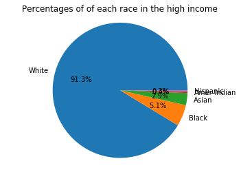

```python
fig, ax = plt.subplots()
ax.pie(res1[0:], labels=res1.keys(), autopct='%1.1f%%')
ax.axis('equal')
ax.set_title('Percentages of of each race in the high income')
plt.show()
```

```python
# income <=50K, race
under_fifty = am_table[am_table['income'] == '<=50K']
res2 = under_fifty['race'].value_counts(normalize=True)*100
pd.DataFrame(res2)
```

|  | race |
| --- | --- |
| White | 83.80 |
| Black | 10.90 |
| Asian | 3.16 |
| Amer-Indian | 1.17 |
| Hispanic | 0.97 |

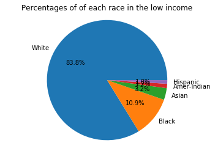

```python
fig, ax = plt.subplots()
ax.pie(res2[0:], labels=res2.keys(), autopct='%1.1f%%')
ax.axis('equal')
ax.set_title('Percentages of of each race in the low income')
plt.show()
```

**Discuss your observations from this analysis:**  
According to the table and the chart above, it can be seen that the majority are from the white race whether they are in the high or low income group. Also, Black, Asian, Amer-Indian, and Hispanic follow the same order in low/high income. If you look closely, the White race in low-income makes up about three times more than the percentage of white race in high-income people. In high or low income scenarios, the order of races remains the same to a large extent.

- **Compare and contrast the characteristics of the low-income and high-income categories across the different attributes**

```python
# income + workclass
percent_income_workclass = pd.crosstab(am_table['income'],am_table['workclass'])/am_table.shape[0]*100
percent_income_workclass
```

| workclass income | Private | Public | Self-emp |
| --- | --- | --- | --- |
| <=50K | 57.83 | 9.83 | 7.70 |
| >50K | 15.98 | 4.16 | 4.49 |

```python
# income >50K, work-class
over_fifty = am_table[am_table['income'] == '>50K']
res3 = over_fifty['workclass'].value_counts(normalize=True)*100
pd.DataFrame(res3)
```

|  | workclass |
| --- | --- |
| Private | 64.86 |
| Self-emp | 18.24 |
| Public | 16.90 |

```python
# incom <=50K, work-class
under_fifty = am_table[am_table['income'] == '<=50K']
res4 = under_fifty['workclass'].value_counts(normalize=True)*100
pd.DataFrame(res4)
```

|  | workclass |
| --- | --- |
| Private | 76.74 |
| Public | 13.04 |
| Self-emp | 10.22 |

```python
# income + marital-status
percent_income_maritalstatus = pd.crosstab(am_table['income'],am_table['marital-status'])/am_table.shape[0]*100
percent_income_maritalstatus
```

| marital-status income | Married | Single |
| --- | --- | --- |
| <=50K | 29.01 | 46.36 |
| >50K | 21.32 | 3.31 |

```python
# income >50K, marital-status
over_fifty = am_table[am_table['income'] == '>50K']
res5 = over_fifty['marital-status'].value_counts(normalize=True)*100
pd.DataFrame(res5)
```

|  | marital-status |
| --- | --- |
| Married | 86.55 |
| Single | 13.45 |

```python
# incom <=50K, marital-status
under_fifty = am_table[am_table['income'] == '<=50K']
res6 = under_fifty['marital-status'].value_counts(normalize=True)*100
pd.DataFrame(res6)
```

|  | marital-status |
| --- | --- |
| Single | 61.51 |
| Married | 38.49 |

```python
# income + sex
percent_income_sex = pd.crosstab(am_table['income'],am_table['sex'])/am_table.shape[0]*100
percent_income_sex
```

| sex income | Female | Male |
| --- | --- | --- |
| <=50K | 28.36 | 47.00 |
| >50K | 3.82 | 20.81 |

```python
# income >50K, sex
over_fifty = am_table[am_table['income'] == '>50K']
res7 = over_fifty['sex'].value_counts(normalize=True)*100
pd.DataFrame(res7)
```

|  | sex |
| --- | --- |
| Male | 84.48 |
| Female | 15.52 |

```python
# incom <=50K, sex
under_fifty = am_table[am_table['income'] == '<=50K']
res8 = under_fifty['sex'].value_counts(normalize=True)*100
pd.DataFrame(res8)
```

|  | sex |
| --- | --- |
| Male | 62.37 |
| Female | 37.63 |

### b. Predictive Modeling and Model Evaluation:

- Create dummy variable for the categorical attributes. Then separate the target attribute(**"income_>50K"**) from the attributes used for training. [Note: you need to drop "**income_<=50K**" which is also created as a dummy variable in earlier steps.] Split the data into training and test sets (80%-20% split)

```python
am_ssf = pd.get_dummies(am_table)
am_ssf
```

|  | age | education | hours-per-week | workclass_Private | workclass_Public | workclass_Self-emp | marital-status_Married | marital-status_Single | race_Amer-Indian | race_Asian | race_Black | race_Hispanic | race_White | sex_Female | sex_Male | income_<=50K | income_>50K |
| --- | --- | --- | --- | --- | --- | --- | --- | --- | --- | --- | --- | --- | --- | --- | --- | --- | --- |
| 0 | 39.00 | 13 | 40 | 0 | 1 | 0 | 0 | 1 | 0 | 0 | 0 | 0 | 1 | 0 | 1 | 1 | 0 |
| 1 | 50.00 | 13 | 13 | 0 | 0 | 1 | 1 | 0 | 0 | 0 | 0 | 0 | 1 | 0 | 1 | 1 | 0 |
| 2 | 38.00 | 9 | 40 | 1 | 0 | 0 | 0 | 1 | 0 | 0 | 0 | 0 | 1 | 0 | 1 | 1 | 0 |
| 3 | 53.00 | 7 | 40 | 1 | 0 | 0 | 1 | 0 | 0 | 0 | 1 | 0 | 0 | 0 | 1 | 1 | 0 |
| 4 | 28.00 | 13 | 40 | 1 | 0 | 0 | 1 | 0 | 0 | 0 | 1 | 0 | 0 | 1 | 0 | 1 | 0 |
| ... | ... | ... | ... | ... | ... | ... | ... | ... | ... | ... | ... | ... | ... | ... | ... | ... | ... |
| 9995 | 38.00 | 10 | 60 | 1 | 0 | 0 | 1 | 0 | 0 | 0 | 0 | 0 | 1 | 0 | 1 | 0 | 1 |
| 9996 | 25.00 | 9 | 8 | 1 | 0 | 0 | 0 | 1 | 0 | 0 | 0 | 0 | 1 | 1 | 0 | 1 | 0 |
| 9997 | 21.00 | 10 | 40 | 1 | 0 | 0 | 0 | 1 | 0 | 0 | 1 | 0 | 0 | 0 | 1 | 1 | 0 |
| 9998 | 38.45 | 2 | 53 | 1 | 0 | 0 | 1 | 0 | 0 | 0 | 0 | 0 | 1 | 0 | 1 | 1 | 0 |
| 9999 | 39.00 | 10 | 40 | 1 | 0 | 0 | 0 | 1 | 0 | 0 | 0 | 0 | 1 | 1 | 0 | 1 | 0 |

9412 rows × 17 columns

```python
am_ssf2 = am_ssf.drop(['income_<=50K'], axis=1)
am_ssf2
```

|  | age | education | hours-per-week | workclass_Private | workclass_Public | workclass_Self-emp | marital-status_Married | marital-status_Single | race_Amer-Indian | race_Asian | race_Black | race_Hispanic | race_White | sex_Female | sex_Male | income_>50K |
| --- | --- | --- | --- | --- | --- | --- | --- | --- | --- | --- | --- | --- | --- | --- | --- | --- |
| 0 | 39.00 | 13 | 40 | 0 | 1 | 0 | 0 | 1 | 0 | 0 | 0 | 0 | 1 | 0 | 1 | 0 |
| 1 | 50.00 | 13 | 13 | 0 | 0 | 1 | 1 | 0 | 0 | 0 | 0 | 0 | 1 | 0 | 1 | 0 |
| 2 | 38.00 | 9 | 40 | 1 | 0 | 0 | 0 | 1 | 0 | 0 | 0 | 0 | 1 | 0 | 1 | 0 |
| 3 | 53.00 | 7 | 40 | 1 | 0 | 0 | 1 | 0 | 0 | 0 | 1 | 0 | 0 | 0 | 1 | 0 |
| 4 | 28.00 | 13 | 40 | 1 | 0 | 0 | 1 | 0 | 0 | 0 | 1 | 0 | 0 | 1 | 0 | 0 |
| ... | ... | ... | ... | ... | ... | ... | ... | ... | ... | ... | ... | ... | ... | ... | ... | ... |
| 9995 | 38.00 | 10 | 60 | 1 | 0 | 0 | 1 | 0 | 0 | 0 | 0 | 0 | 1 | 0 | 1 | 1 |
| 9996 | 25.00 | 9 | 8 | 1 | 0 | 0 | 0 | 1 | 0 | 0 | 0 | 0 | 1 | 1 | 0 | 0 |
| 9997 | 21.00 | 10 | 40 | 1 | 0 | 0 | 0 | 1 | 0 | 0 | 1 | 0 | 0 | 0 | 1 | 0 |
| 9998 | 38.45 | 2 | 53 | 1 | 0 | 0 | 1 | 0 | 0 | 0 | 0 | 0 | 1 | 0 | 1 | 0 |
| 9999 | 39.00 | 10 | 40 | 1 | 0 | 0 | 0 | 1 | 0 | 0 | 0 | 0 | 1 | 1 | 0 | 0 |

9412 rows × 16 columns

```python
target_income = am_ssf2['income_>50K']
target_income
```

```
0       0
1       0
2       0
3       0
4       0
       ..
9995    1
9996    0
9997    0
9998    0
9999    0
Name: income_>50K, Length: 9412, dtype: uint8
```

```python
am_matrix = am_ssf2 = am_ssf2.drop(['income_>50K'], axis=1)
am_matrix
```

|  | age | education | hours-per-week | workclass_Private | workclass_Public | workclass_Self-emp | marital-status_Married | marital-status_Single | race_Amer-Indian | race_Asian | race_Black | race_Hispanic | race_White | sex_Female | sex_Male |
| --- | --- | --- | --- | --- | --- | --- | --- | --- | --- | --- | --- | --- | --- | --- | --- |
| 0 | 39.00 | 13 | 40 | 0 | 1 | 0 | 0 | 1 | 0 | 0 | 0 | 0 | 1 | 0 | 1 |
| 1 | 50.00 | 13 | 13 | 0 | 0 | 1 | 1 | 0 | 0 | 0 | 0 | 0 | 1 | 0 | 1 |
| 2 | 38.00 | 9 | 40 | 1 | 0 | 0 | 0 | 1 | 0 | 0 | 0 | 0 | 1 | 0 | 1 |
| 3 | 53.00 | 7 | 40 | 1 | 0 | 0 | 1 | 0 | 0 | 0 | 1 | 0 | 0 | 0 | 1 |
| 4 | 28.00 | 13 | 40 | 1 | 0 | 0 | 1 | 0 | 0 | 0 | 1 | 0 | 0 | 1 | 0 |
| ... | ... | ... | ... | ... | ... | ... | ... | ... | ... | ... | ... | ... | ... | ... | ... |
| 9995 | 38.00 | 10 | 60 | 1 | 0 | 0 | 1 | 0 | 0 | 0 | 0 | 0 | 1 | 0 | 1 |
| 9996 | 25.00 | 9 | 8 | 1 | 0 | 0 | 0 | 1 | 0 | 0 | 0 | 0 | 1 | 1 | 0 |
| 9997 | 21.00 | 10 | 40 | 1 | 0 | 0 | 0 | 1 | 0 | 0 | 1 | 0 | 0 | 0 | 1 |
| 9998 | 38.45 | 2 | 53 | 1 | 0 | 0 | 1 | 0 | 0 | 0 | 0 | 0 | 1 | 0 | 1 |
| 9999 | 39.00 | 10 | 40 | 1 | 0 | 0 | 0 | 1 | 0 | 0 | 0 | 0 | 1 | 1 | 0 |

9412 rows × 15 columns

```python
# Split the data into training and test sets(80%-20%)
am_train, am_test, am_target_train, am_target_test = train_test_split(am_matrix, target_income, test_size=0.2, random_state=33)
print(am_test.shape, am_train.shape)
am_test[0:5]
```

```
(1883, 15) (7529, 15)
```

|  | age | education | hours-per-week | workclass_Private | workclass_Public | workclass_Self-emp | marital-status_Married | marital-status_Single | race_Amer-Indian | race_Asian | race_Black | race_Hispanic | race_White | sex_Female | sex_Male |
| --- | --- | --- | --- | --- | --- | --- | --- | --- | --- | --- | --- | --- | --- | --- | --- |
| 8419 | 56.0 | 10 | 45 | 1 | 0 | 0 | 1 | 0 | 0 | 0 | 0 | 0 | 1 | 0 | 1 |
| 2629 | 54.0 | 9 | 45 | 1 | 0 | 0 | 1 | 0 | 0 | 0 | 0 | 0 | 1 | 0 | 1 |
| 2523 | 52.0 | 11 | 35 | 1 | 0 | 0 | 0 | 1 | 0 | 0 | 0 | 0 | 1 | 1 | 0 |
| 7143 | 42.0 | 16 | 60 | 0 | 0 | 1 | 1 | 0 | 0 | 0 | 0 | 0 | 1 | 0 | 1 |
| 5902 | 30.0 | 9 | 50 | 0 | 0 | 1 | 1 | 0 | 0 | 0 | 0 | 0 | 1 | 0 | 1 |

```python
min_max_scaler = preprocessing.MinMaxScaler().fit(am_train)

am_train_norm = min_max_scaler.transform(am_train)
am_train_norm = pd.DataFrame(am_train_norm, columns=am_train.columns, index=am_train.index)

am_test_norm = min_max_scaler.transform(am_test)
am_test_norm = pd.DataFrame(am_test_norm, columns=am_test.columns, index=am_test.index)
```

```python
am_train_norm.head()
```

|  | age | education | hours-per-week | workclass_Private | workclass_Public | workclass_Self-emp | marital-status_Married | marital-status_Single | race_Amer-Indian | race_Asian | race_Black | race_Hispanic | race_White | sex_Female | sex_Male |
| --- | --- | --- | --- | --- | --- | --- | --- | --- | --- | --- | --- | --- | --- | --- | --- |
| 287 | 0.45 | 0.60 | 0.45 | 1.0 | 0.0 | 0.0 | 0.0 | 1.0 | 0.0 | 0.0 | 0.0 | 0.0 | 1.0 | 0.0 | 1.0 |
| 7852 | 0.33 | 0.53 | 0.40 | 1.0 | 0.0 | 0.0 | 0.0 | 1.0 | 0.0 | 0.0 | 0.0 | 0.0 | 1.0 | 1.0 | 0.0 |
| 5887 | 0.29 | 0.53 | 0.50 | 0.0 | 1.0 | 0.0 | 0.0 | 1.0 | 0.0 | 0.0 | 0.0 | 0.0 | 1.0 | 0.0 | 1.0 |
| 4791 | 0.37 | 0.53 | 0.40 | 1.0 | 0.0 | 0.0 | 0.0 | 1.0 | 0.0 | 0.0 | 0.0 | 0.0 | 1.0 | 1.0 | 0.0 |
| 6540 | 0.05 | 0.60 | 0.45 | 1.0 | 0.0 | 0.0 | 0.0 | 1.0 | 0.0 | 0.0 | 0.0 | 0.0 | 1.0 | 0.0 | 1.0 |

```python
am_test_norm.head()
```

|  | age | education | hours-per-week | workclass_Private | workclass_Public | workclass_Self-emp | marital-status_Married | marital-status_Single | race_Amer-Indian | race_Asian | race_Black | race_Hispanic | race_White | sex_Female | sex_Male |
| --- | --- | --- | --- | --- | --- | --- | --- | --- | --- | --- | --- | --- | --- | --- | --- |
| 8419 | 0.53 | 0.60 | 0.45 | 1.0 | 0.0 | 0.0 | 1.0 | 0.0 | 0.0 | 0.0 | 0.0 | 0.0 | 1.0 | 0.0 | 1.0 |
| 2629 | 0.51 | 0.53 | 0.45 | 1.0 | 0.0 | 0.0 | 1.0 | 0.0 | 0.0 | 0.0 | 0.0 | 0.0 | 1.0 | 0.0 | 1.0 |
| 2523 | 0.48 | 0.67 | 0.35 | 1.0 | 0.0 | 0.0 | 0.0 | 1.0 | 0.0 | 0.0 | 0.0 | 0.0 | 1.0 | 1.0 | 0.0 |
| 7143 | 0.34 | 1.00 | 0.60 | 0.0 | 0.0 | 1.0 | 1.0 | 0.0 | 0.0 | 0.0 | 0.0 | 0.0 | 1.0 | 0.0 | 1.0 |
| 5902 | 0.18 | 0.53 | 0.50 | 0.0 | 0.0 | 1.0 | 1.0 | 0.0 | 0.0 | 0.0 | 0.0 | 0.0 | 1.0 | 0.0 | 1.0 |

- **Use scikit-learn to build classifiers using** `Naive Bayes (Gaussian), decision tree` **(using** "`gini`" **as selection criteria), and** `linear discriminant analysis (LDA)`**. For each of these perform** `10-fold cross-validation` **on the training data and report the overall aberage accuracy. Compare this to the model accuracy on the training data. Finally, run your model on the set-aside test data.**

> **Naive Bayes (Gaussian)**

```python
from sklearn.model_selection import cross_val_score

nbclf = naive_bayes.GaussianNB()
cv_scores = cross_val_score(nbclf, am_matrix, target_income, cv=10)
print(cv_scores)
```

```
[0.73 0.7  0.73 0.71 0.73 0.71 0.71 0.72 0.73 0.71]
```

```python
nbclf = nbclf.fit(am_train, am_target_train)
print("Accuracy on Training: ", nbclf.score(am_train, am_target_train))
print("Accuracy on Test:     ", nbclf.score(am_test, am_target_test))
print("Overall Accuracy on X-Val: %0.2f (+/- %0.2f)" % (cv_scores.mean(), cv_scores.std()*2))
```

```
Accuracy on Training:  0.720547217425953
Accuracy on Test:      0.7190653212958046
Overall Accuracy on X-Val: 0.72 (+/- 0.02)
```

```python
# run your model on the set-aside test data
nbcpreds_test = nbclf.predict(am_test)
print(nbcpreds_test)
```

```
[1 1 0 ... 1 0 1]
```

```python
print(classification_report(am_target_test, nbcpreds_test))
```

```
              precision    recall  f1-score   support

           0       0.90      0.71      0.80      1443
           1       0.44      0.74      0.55       440

    accuracy                           0.72      1883
   macro avg       0.67      0.73      0.67      1883
weighted avg       0.79      0.72      0.74      1883
```

```python
nbcm = confusion_matrix(am_target_test,nbcpreds_test)
print(nbcm)
```

```
[[1027  416]
 [ 113  327]]
```

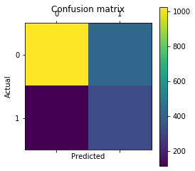

```python
import pylab as plt
%matplotlib inline
plt.matshow(nbcm)
plt.title('Confusion matrix')
plt.colorbar()
plt.ylabel('Actual')
plt.xlabel('Predicted')
plt.show()
```

> **Decision Tree (using "gini")**

```python
from sklearn import neighbors, tree, naive_bayes

treeclf = tree.DecisionTreeClassifier(criterion='gini')
cv_scores = cross_val_score(treeclf, am_matrix, target_income, cv=10)
print(cv_scores)
```

```
[0.75 0.76 0.77 0.78 0.77 0.77 0.75 0.78 0.77 0.77]
```

```python
treeclf = treeclf.fit(am_train, am_target_train)
print("Accuracy on Training: ", treeclf.score(am_train, am_target_train))
print("Accuracy on Test:     ", treeclf.score(am_test, am_target_test))
print("Overall Accuracy on X-Val: %0.2f (+/- %0.2f)" % (cv_scores.mean(), cv_scores.std()*2))
```

```
Accuracy on Training:  0.942887501660247
Accuracy on Test:      0.7679235262878386
Overall Accuracy on X-Val: 0.77 (+/- 0.02)
```

```python
# run your model on the set-aside test data
treepreds_test = treeclf.predict(am_test)
print(treepreds_test)
```

```
[0 1 0 ... 0 0 1]
```

```python
print(classification_report(am_target_test, treepreds_test))
```

```
              precision    recall  f1-score   support

           0       0.83      0.87      0.85      1443
           1       0.50      0.44      0.47       440

    accuracy                           0.77      1883
   macro avg       0.67      0.65      0.66      1883
weighted avg       0.76      0.77      0.76      1883
```

```python
treecm = confusion_matrix(am_target_test,treepreds_test)
print(treecm)
```

```
[[1254  189]
 [ 248  192]]
```

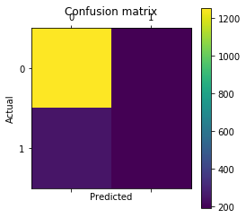

```python
import pylab as plt
%matplotlib inline
plt.matshow(treecm)
plt.title('Confusion matrix')
plt.colorbar()
plt.ylabel('Actual')
plt.xlabel('Predicted')
plt.show()
```

> **Linear discriminant analysis (LDA)**

```python
from sklearn.discriminant_analysis import LinearDiscriminantAnalysis

ldclf = LinearDiscriminantAnalysis()
cv_scores = cross_val_score(ldclf, am_matrix, target_income, cv=10)
print(cv_scores)
```

```
[0.81 0.81 0.79 0.82 0.81 0.79 0.8  0.81 0.82 0.82]
```

```python
ldclf = ldclf.fit(am_train, am_target_train)
print("Accuracy on Training: ", ldclf.score(am_train, am_target_train))
print("Accuracy on Test:     ", ldclf.score(am_test, am_target_test))
print("Overall Accuracy on X-Val: %0.2f (+/- %0.2f)" % (cv_scores.mean(), cv_scores.std()*2))
```

```
Accuracy on Training:  0.8063487846991633
Accuracy on Test:      0.8109399893786511
Overall Accuracy on X-Val: 0.81 (+/- 0.02)
```

```python
# run your model on the set-aside test data
ldapreds_test = treeclf.predict(am_test)
print(ldapreds_test)
```

```
[0 1 0 ... 0 0 1]
```

```python
print(classification_report(am_target_test, ldapreds_test))
```

```
              precision    recall  f1-score   support

           0       0.83      0.87      0.85      1443
           1       0.50      0.44      0.47       440

    accuracy                           0.77      1883
   macro avg       0.67      0.65      0.66      1883
weighted avg       0.76      0.77      0.76      1883
```

```python
ldacm = confusion_matrix(am_target_test, ldapreds_test)
print(ldacm)
```

```
[[1254  189]
 [ 248  192]]
```

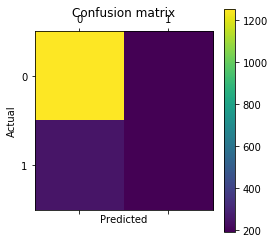

```python
import pylab as plt
%matplotlib inline
plt.matshow(ldacm)
plt.title('Confusion matrix')
plt.colorbar()
plt.ylabel('Actual')
plt.xlabel('Predicted')
plt.show()
```